# DISEÑO DEL PROYECTO

Este caso se presenta para una empresa inmobiliaria que hace inversiones en grandes ciudades comprando inmuebles para posteriormente alquilarlos como alojamientos turísticos.

La dirección ha tomado la decisión de invertir en Madrid y ha encargado analizar los datos que el líder del sector AirBnb hace públicos, para intentar encontrar los tipos de inmuebles que tienen mayor potencial comercial de alquier turístico.

Como entregable principal se espera la tipología (o tipologías) de inmuebles que el equipo de valoraciones debe buscar entre las oportunidades existentes en la ciudad y los principales barrios o zonas geográficas en las que focalizarse.

Para cumplir con el objetivo se aplicará la metodología de Discovery y técnicas de Business Analytics.

Aunque este caso concreto está centrado en el alquiler turístico, el mismo tipo de aproximación se puede usar en casos que tengan un alto componente de "ubicación":

- apertura y cierre de tiendas
- reducción de capacidad instalada
- expansión de franquicias
- etc.

## OBJETIVO

Localizar el perfil (o perfiles) de inmuebles que maximizan el potencial comercial en el mercado del alquiler turístico y las principales zonas de ubicación.

## PALANCAS

El equipo de valoraciones indica que las palancas que tienen mayor impacto en la rentabilidad de este tipo de inversiones son:

- **Precio alquiler**: cuánto más se pueda cobrar por noche mayor es la rentabilidad.
- **Ocupación**: en general, cuántos más días al año se pueda alquilar un inmueble mayor es su rentabilidad.
- **Precio inmueble**: cuánto más barato se pueda adquirir la propiedad mayor es la rentabilidad.

## KPIs

En este ejemplo los KPIs son bastante directos:

- Se medirá la ocupación como el número de días anuales que el inmueble se pueda alquilar.
- Se medirá el precio del alquiler como el precio por noche en euros según Airbnb.
- Se medirá el precio de un inmueble como la multiplicación entre el número de metros cuadrados y el precio medio del m2 en su zona, y se aplicará un 25% de descuento sobre el precio oficial por la fuerza de negociación del equipo de compras.

## ENTIDADES Y DATOS

Las entidades relevantes para el objetivo y de datos disponibles son:

- Inmuebles
- Propietarios
- Distritos

Los datos concretos en cada uno de ellos se revisarán más adelante durante el desarrollo del proyecto.

## PREGUNTAS SEMILLA

**Sobre el precio del alquiler:**

- ¿Cual es el precio medio? ¿y el rango de precios? ¿Y por distritos? ¿Y por barrios?
- ¿Cual es el ranking de distritos y barrios por precio medio de alquiler?
- ¿Qué factores (a parte de la localización determinan el precio del alquiler?
- ¿Cual es la relación entre el tamaño del inmueble y el precio por el que se puede alquilar?
- ¿Cómo influye la competencia (num inmuebles disponibles por barrio) sobre el precio del alquiler?
- ¿Cómo varían los precios por tipo de alquiler (todo el piso, habitación privada, habitación compartida)?

**Sobre la ocupación:**

- ¿Cual es la ocupación media? ¿Y por distritos? ¿Y por barrios?
- ¿Cómo de probable es cada nivel de ocupación en cada distrito?
- ¿Cual es el ranking de distritos y barrios por ocupación?
- ¿Qué factores (a parte de la localización determinan la ocupación?
- ¿Cual es la relación entre el tamaño del inmueble y su grado de ocupación?
- ¿Cómo influye la competencia (num inmuebles disponibles por barrio) sobre la ocupación?

**Sobre el precio de compra:**

- ¿Cual es el ranking de precio por m2 por distrito?
- ¿Cual es el ranking de precio del inmueble (m2 * tamaño medio) por distrito?
- ¿Cual es la relación entre el precio del inmueble y el precio del alquiler por distrito?
- ¿Cual es la relación entre el precio del inmueble y la ocupación por distrito?

## ANÁLISIS INICIAL DE FICHEROS Y PREPARACIÓN DEL CASO

Se usarán datos reales ofrecidos por AirBnB en la página: http://insideairbnb.com/get-the-data.html

Concretamente se estudiará la ciudad de Madrid, pero es posible encontrar en la página muchas otras ciudades, por si existe interés en replicar el trabajo con una localización más significativa en otros casos.

A efectos del objetivo de proyecto, se realizarán modificaciones en los datos para:

- Seleccionar únicamente las tablas que vayan a resultar útiles.
- Cargar toda la información en una base de datos, éste será el formato más habitual en entornos empresariales.

## SetUp

### Entendiendo los Ficheros

En la web de AirBnB es posible ver la descripción de las tablas:

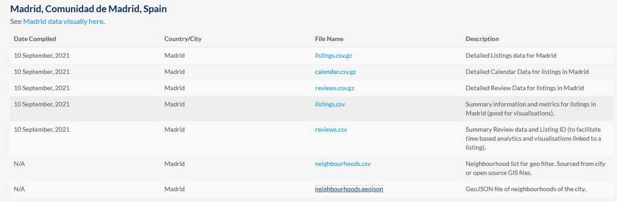

Se cargarán una a una, se analizarán, se entenderán y se tomará la decisión de uso.

### Carga y revisión inicial del fichero listings general

|  | id | name | host_id | host_name | neighbourhood_group | neighbourhood | latitude | longitude | room_type | price | minimum_nights | number_of_reviews | last_review | reviews_per_month | calculated_host_listings_count | availability_365 | number_of_reviews_ltm | license |
| --- | --- | --- | --- | --- | --- | --- | --- | --- | --- | --- | --- | --- | --- | --- | --- | --- | --- | --- |
| 0 | 6369 | Rooftop terrace room , ensuite bathroom | 13660 | Simon | Chamartín | Hispanoamérica | 40.45724 | -3.67688 | Private room | 60 | 1 | 80 | 2019-05-14 | 1.21 | 2 | 180 | 4 | NaN |
| 1 | 21853 | Bright and airy room | 83531 | Abdel | Latina | Cármenes | 40.40381 | -3.74130 | Private room | 31 | 4 | 33 | 2018-05-29 | 0.39 | 2 | 364 | 0 | NaN |
| 2 | 23001 | Apartmento Arganzuela- Madrid Rio | 82175 | Jesus | Arganzuela | Legazpi | 40.38840 | -3.69511 | Entire home/apt | 50 | 15 | 0 | NaN | NaN | 5 | 222 | 0 | NaN |
| 3 | 24805 | Gran Via Studio Madrid | 346366726 | A | Centro | Universidad | 40.42183 | -3.70529 | Entire home/apt | 92 | 5 | 12 | 2020-03-01 | 0.51 | 1 | 115 | 2 | NaN |
| 4 | 26825 | Single Room whith private Bathroom | 114340 | Agustina | Arganzuela | Legazpi | 40.38975 | -3.69018 | Private room | 26 | 2 | 149 | 2018-05-15 | 1.65 | 1 | 349 | 0 | NaN |

```
<class 'pandas.core.frame.DataFrame'>
RangeIndex: 18909 entries, 0 to 18908
Data columns (total 18 columns):
 #   Column                          Non-Null Count  Dtype
---  ------                          --------------  -----
 0   id                              18909 non-null  int64
 1   name                            18906 non-null  object
 2   host_id                         18909 non-null  int64
 3   host_name                       18883 non-null  object
 4   neighbourhood_group             18909 non-null  object
 5   neighbourhood                   18909 non-null  object
 6   latitude                        18909 non-null  float64
 7   longitude                       18909 non-null  float64
 8   room_type                       18909 non-null  object
 9   price                           18909 non-null  int64
 10  minimum_nights                  18909 non-null  int64
 11  number_of_reviews               18909 non-null  int64
 12  last_review                     13877 non-null  object
 13  reviews_per_month               13877 non-null  float64
 14  calculated_host_listings_count  18909 non-null  int64
 15  availability_365                18909 non-null  int64
 16  number_of_reviews_ltm           18909 non-null  int64
 17  license                         2828 non-null   object
dtypes: float64(3), int64(8), object(7)
memory usage: 2.6+ MB
```

### Carga y revisión inicial del fichero listings detalle

|  | id | listing_url | scrape_id | last_scraped | name | description | neighborhood_overview | picture_url | host_id | host_url | host_name | host_since | host_location | host_about | host_response_time | host_response_rate | host_acceptance_rate | host_is_superhost | host_thumbnail_url | host_picture_url | host_neighbourhood | host_listings_count | host_total_listings_count | host_verifications | host_has_profile_pic | host_identity_verified | neighbourhood | neighbourhood_cleansed | neighbourhood_group_cleansed | … |
| --- | --- | --- | --- | --- | --- | --- | --- | --- | --- | --- | --- | --- | --- | --- | --- | --- | --- | --- | --- | --- | --- | --- | --- | --- | --- | --- | --- | --- | --- | --- |
| 0 | 6369 | https://www.airbnb.com/rooms/6369 | 20210910193531 | 2021-09-11 | Rooftop terrace room , ensuite bathroom | Excellent connection with the AIRPORT and EXHI... | NaN | https://a0.muscache.com/pictures/683224/4cc318... | 13660 | https://www.airbnb.com/users/show/13660 | Simon | 2009-04-16 | Madrid, Community of Madrid, Spain | Gay couple, heterofriendly, enjoy having guest... | within a few hours | 100% | 83% | t | https://a0.muscache.com/im/pictures/user/1c793... | https://a0.muscache.com/im/pictures/user/1c793... | Hispanoamérica | 1.0 | 1.0 | ['email', 'phone', 'reviews', 'jumio', 'offlin... | t | t | NaN | Hispanoamérica | Chamartín | … |
| 1 | 21853 | https://www.airbnb.com/rooms/21853 | 20210910193531 | 2021-09-11 | Bright and airy room | We have a quiet and sunny room with a good vie... | We live in a leafy neighbourhood with plenty o... | https://a0.muscache.com/pictures/68483181/87bc... | 83531 | https://www.airbnb.com/users/show/83531 | Abdel | 2010-02-21 | Madrid, Madrid, Spain | EN-ES-FR\r\nEN\r\nHi everybody: I'm Abdel. I'm... | NaN | NaN | NaN | f | https://a0.muscache.com/im/users/83531/profile... | https://a0.muscache.com/im/users/83531/profile... | Aluche | 2.0 | 2.0 | ['email', 'phone', 'reviews', 'manual_offline'... | t | t | Madrid, Spain | Cármenes | Latina | … |
| 2 | 23001 | https://www.airbnb.com/rooms/23001 | 20210910193531 | 2021-09-11 | Apartmento Arganzuela- Madrid Rio | Apartamento de tres dormitorios dobles, gran s... | Barrio Arganzuela, junto a Madrid Rio, zonas c... | https://a0.muscache.com/pictures/58e6a770-509c... | 82175 | https://www.airbnb.com/users/show/82175 | Jesus | 2010-02-17 | Madrid, Community of Madrid, Spain | Hi,\r\n\r\nWelcome to my apartments in the dow... | within a few hours | 97% | 64% | f | https://a0.muscache.com/im/pictures/user/52bdf... | https://a0.muscache.com/im/pictures/user/52bdf... | Legazpi | 10.0 | 10.0 | ['email', 'phone', 'reviews', 'jumio', 'offlin... | t | t | Madrid, Comunidad de Madrid, Spain | Legazpi | Arganzuela | … |
| 3 | 24805 | https://www.airbnb.com/rooms/24805 | 20210910193531 | 2021-09-11 | Gran Via Studio Madrid | Studio located 50 meters from Gran Via, next t... | The area is next to the Gran Via, so people li... | https://a0.muscache.com/pictures/miso/Hosting-... | 346366726 | https://www.airbnb.com/users/show/346366726 | A | 2020-05-15 | ES | NaN | NaN | NaN | NaN | f | https://a0.muscache.com/im/pictures/user/d3167... | https://a0.muscache.com/im/pictures/user/d3167... | NaN | 1.0 | 1.0 | ['email', 'phone'] | t | f | Madrid, Spain | Universidad | Centro | … |
| 4 | 26825 | https://www.airbnb.com/rooms/26825 | 20210910193531 | 2021-09-11 | Single Room whith private Bathroom | Nice and cozy roon for one person with a priva... | Es un barrio muy tranquilo, en una zona de Mad... | https://a0.muscache.com/pictures/149358/218d5b... | 114340 | https://www.airbnb.com/users/show/114340 | Agustina | 2010-04-27 | Madrid, Madrid, Spain | I like Fine art, Photography, Cinema, travel a... | within an hour | 100% | 50% | f | https://a0.muscache.com/im/users/114340/profil... | https://a0.muscache.com/im/users/114340/profil... | Legazpi | 1.0 | 1.0 | ['email', 'phone', 'reviews', 'jumio', 'govern... | t | t | Madrid, Comunidad de Madrid, Spain | Legazpi | Arganzuela | … |

```
<class 'pandas.core.frame.DataFrame'>
RangeIndex: 18909 entries, 0 to 18908
Data columns (total 74 columns):
 #   Column                                        Non-Null Count  Dtype
---  ------                                        --------------  -----
 0   id                                            18909 non-null  int64
 1   listing_url                                   18909 non-null  object
 2   scrape_id                                     18909 non-null  int64
 3   last_scraped                                  18909 non-null  object
 4   name                                          18906 non-null  object
 5   description                                   17854 non-null  object
 6   neighborhood_overview                         10997 non-null  object
 7   picture_url                                   18908 non-null  object
 8   host_id                                       18909 non-null  int64
 9   host_url                                      18909 non-null  object
```

[output cut: 66 more lines]

Conclusiones:

- Son los mismos registros pero el fichero de detalle tiene más columnas.
- Es posible unirlos por medio del campo id.

### Carga y revisión inicial del fichero reviews general

|  | listing_id | date |
| --- | --- | --- |
| 0 | 6369 | 2010-03-14 |
| 1 | 6369 | 2010-03-23 |
| 2 | 6369 | 2010-04-10 |
| 3 | 6369 | 2010-04-21 |
| 4 | 6369 | 2010-04-26 |

```
<class 'pandas.core.frame.DataFrame'>
RangeIndex: 618440 entries, 0 to 618439
Data columns (total 2 columns):
 #   Column      Non-Null Count   Dtype
---  ------      --------------   -----
 0   listing_id  618440 non-null  int64
 1   date        618440 non-null  object
dtypes: int64(1), object(1)
memory usage: 9.4+ MB
```

### Carga y revisión inicial del fichero reviews detalle

|  | listing_id | id | date | reviewer_id | reviewer_name | comments |
| --- | --- | --- | --- | --- | --- | --- |
| 0 | 6369 | 29428 | 2010-03-14 | 84790 | Nancy | Simon and Arturo have the ultimate location in... |
| 1 | 6369 | 31018 | 2010-03-23 | 84338 | David | Myself and Kristy originally planned on stayin... |
| 2 | 6369 | 34694 | 2010-04-10 | 98655 | Marion | We had a great time at Arturo and Simon's ! A ... |
| 3 | 6369 | 37146 | 2010-04-21 | 109871 | Kurt | I very much enjoyed the stay. \r<br/>It's a w... |
| 4 | 6369 | 38168 | 2010-04-26 | 98901 | Dennis | Arturo and Simon are polite and friendly hosts... |

```
<class 'pandas.core.frame.DataFrame'>
RangeIndex: 618440 entries, 0 to 618439
Data columns (total 6 columns):
 #   Column         Non-Null Count   Dtype
---  ------         --------------   -----
 0   listing_id     618440 non-null  int64
 1   id             618440 non-null  int64
 2   date           618440 non-null  object
 3   reviewer_id    618440 non-null  int64
 4   reviewer_name  618439 non-null  object
 5   comments       618048 non-null  object
dtypes: int64(3), object(3)
memory usage: 28.3+ MB
```

Conclusiones:

- Son los mismos registros, pero el fichero de detalle tiene más columnas.
- Realmente la info de las reseñas no aporta en medida relevante al objetivo, así que se descarta el uso de estas tablas.

### Carga y revisión inicial del fichero calendar

|  | listing_id | date | available | price | adjusted_price | minimum_nights | maximum_nights |
| --- | --- | --- | --- | --- | --- | --- | --- |
| 0 | 6369 | 2024-09-11 | t | $60.00 | $60.00 | 1 | 1125 |
| 1 | 6369 | 2024-09-12 | t | $60.00 | $60.00 | 1 | 1125 |
| 2 | 6369 | 2024-09-13 | t | $60.00 | $60.00 | 1 | 1125 |
| 3 | 6369 | 2024-09-14 | t | $60.00 | $60.00 | 1 | 1125 |
| 4 | 6369 | 2024-09-15 | t | $60.00 | $60.00 | 1 | 1125 |
| 5 | 6369 | 2024-09-16 | t | $60.00 | $60.00 | 1 | 1125 |
| 6 | 6369 | 2024-09-17 | t | $60.00 | $60.00 | 1 | 1125 |
| 7 | 6369 | 2024-09-18 | t | $60.00 | $60.00 | 1 | 1125 |
| 8 | 6369 | 2024-09-19 | t | $60.00 | $60.00 | 1 | 1125 |
| 9 | 6369 | 2024-09-20 | t | $60.00 | $60.00 | 1 | 1125 |
| 10 | 6369 | 2024-09-21 | t | $60.00 | $60.00 | 1 | 1125 |
| 11 | 6369 | 2024-09-22 | t | $60.00 | $60.00 | 1 | 1125 |
| 12 | 6369 | 2024-09-23 | t | $60.00 | $60.00 | 1 | 1125 |
| 13 | 6369 | 2024-09-24 | t | $60.00 | $60.00 | 1 | 1125 |
| 14 | 6369 | 2024-09-25 | t | $60.00 | $60.00 | 1 | 1125 |

```
<class 'pandas.core.frame.DataFrame'>
RangeIndex: 6901414 entries, 0 to 6901413
Data columns (total 7 columns):
 #   Column          Dtype
---  ------          -----
 0   listing_id      int64
 1   date            object
 2   available       object
 3   price           object
 4   adjusted_price  object
 5   minimum_nights  int64
 6   maximum_nights  int64
dtypes: int64(3), object(4)
memory usage: 368.6+ MB
```

Conclusiones:

- Esta tabla se proyecta hacia el futuro, al parecer contiene la disponibilidad de reservas.
- No es información útil para el fin del proyecto, por tanto no se usará.

### Carga y revisión inicial del fichero neighborhoods

|  | neighbourhood_group | neighbourhood |
| --- | --- | --- |
| 0 | Arganzuela | Acacias |
| 1 | Arganzuela | Atocha |
| 2 | Arganzuela | Chopera |
| 3 | Arganzuela | Delicias |
| 4 | Arganzuela | Imperial |

Conclusiones:

- Es un maestro de vecindario y grupo de vecindario.
- En principio no se usará, tanto el vecindario como su grupo ya están incorporados en otras tablas.

### Carga y revisión inicial del fichero neighborhoods.geojson

|  | type | features |
| --- | --- | --- |
| 0 | FeatureCollection | {'type': 'Feature', 'geometry': {'type': 'Mult... |
| 1 | FeatureCollection | {'type': 'Feature', 'geometry': {'type': 'Mult... |
| 2 | FeatureCollection | {'type': 'Feature', 'geometry': {'type': 'Mult... |
| 3 | FeatureCollection | {'type': 'Feature', 'geometry': {'type': 'Mult... |
| 4 | FeatureCollection | {'type': 'Feature', 'geometry': {'type': 'Mult... |

```
<class 'pandas.core.frame.DataFrame'>
RangeIndex: 128 entries, 0 to 127
Data columns (total 2 columns):
 #   Column    Non-Null Count  Dtype
---  ------    --------------  -----
 0   type      128 non-null    object
 1   features  128 non-null    object
dtypes: object(2)
memory usage: 2.1+ KB
```

Conclusiones:

- Al parecer contiene información geométrica para construcción de mapas.
- Se realizarán mapas con base en coordenadas geográficas, no mediante información geométrica, por tal motivo se descarta del análisis la anterior tabla.

### Conclusiones del análisis de ficheros

Tablas principales que usaremos:

- listings.csv
- listings_det.csv

## Creación de una Base de Datos

Se almacenarán las tablas seleccionadas en una base de datos.

Se usará la base de datos sqlite.

Se Crea la conexión:

Se crean las tablas y se cargan los datos

### Crear las tablas y cargar los datos

```
18909
```

# CREACIÓN DEL DATAMART ANALÍTICO

A partir de este punto, se inicia el desarrollo del proyecto.

Es posible unir los datos en esta fase y crear el "tablón analítico" para realizar después la calidad de datos, ya que los datos no son masivos.

Pero, como buena práctica, es recomendable realizar primero la calidad de datos individual de cada tabla, sobre todo porque si el volumen fuera muy alto, al unirlos se multiplicarán más.

Por tanto, inicialmente se dejarán como tablas individuales, después se aplicará calidad de datos y finalmente se unirán para forma el tablón, o más oficialmente, el datamart analítico.

Entonces:

1. Acceder a la base de datos
2. Importar los datos
3. Realizar la calidad de datos
4. Crear el datamart analítico
5. Guardar como una nueva tabla en la base de datos

# Importación de los datos

## Datos internos

Crear la conexión a la base de datos

```
['df', 'df_preparado', 'listings', 'listings_det']
```

## Datos Externos

En los datos no se dispone del precio de compra de un inmueble, pero se definió como una de las palancas principales.

Por tanto, se buscarán dichos datos de forma externa.

La siguiente página incluye la información requerida: https://www.idealista.com/sala-de-prensa/informes-precio-vivienda/venta/madrid-comunidad/madrid-provincia/madrid/

Es posible extraerla mediante web scraping y guardarla en el archivo de datos del proyecto.

Se cargan los datos y se seleccionan únicamente las columnas de precio y distrito.

|  | precio_m2 | distrito |
| --- | --- | --- |
| 1 | 4.085 €/m2 | Arganzuela |
| 2 | 3.409 €/m2 | Barajas |
| 3 | 2.123 €/m2 | Carabanchel |
| 4 | 4.827 €/m2 | Centro |
| 5 | 5.098 €/m2 | Chamartín |
| 6 | 5.381 €/m2 | Chamberí |
| 7 | 2.940 €/m2 | Ciudad Lineal |
| 8 | 3.568 €/m2 | Fuencarral |
| 9 | 3.871 €/m2 | Hortaleza |
| 10 | 2.267 €/m2 | Latina |
| 11 | 4.033 €/m2 | Moncloa |
| 12 | 2.500 €/m2 | Moratalaz |
| 13 | 1.918 €/m2 | Puente de Vallecas |
| 14 | 4.788 €/m2 | Retiro |
| 15 | 6.114 €/m2 | Salamanca |
| 16 | 2.591 €/m2 | San Blas |
| 17 | 3.678 €/m2 | Tetuán |
| 18 | 1.995 €/m2 | Usera |
| 19 | 2.403 €/m2 | Vicálvaro |
| 20 | 2.354 €/m2 | Villa de Vallecas |
| 21 | 1.693 €/m2 | Villaverde |

Se limpia el precio:

1. quitando la unidad
2. quitando los puntos de separador de miles
3. cambiando el tipo a entero

### Limpieza fichero precio_m2

|  | precio_m2 | distrito |
| --- | --- | --- |
| 1 | 4085 | Arganzuela |
| 2 | 3409 | Barajas |
| 3 | 2123 | Carabanchel |
| 4 | 4827 | Centro |
| 5 | 5098 | Chamartín |
| 6 | 5381 | Chamberí |
| 7 | 2940 | Ciudad Lineal |
| 8 | 3568 | Fuencarral |
| 9 | 3871 | Hortaleza |
| 10 | 2267 | Latina |
| 11 | 4033 | Moncloa |
| 12 | 2500 | Moratalaz |
| 13 | 1918 | Puente de Vallecas |
| 14 | 4788 | Retiro |
| 15 | 6114 | Salamanca |
| 16 | 2591 | San Blas |
| 17 | 3678 | Tetuán |
| 18 | 1995 | Usera |
| 19 | 2403 | Vicálvaro |
| 20 | 2354 | Villa de Vallecas |
| 21 | 1693 | Villaverde |

# Calidad de Datos

### Visión general tabla listings

|  | index | id | name | host_id | host_name | neighbourhood_group | neighbourhood | latitude | longitude | room_type | price | minimum_nights | number_of_reviews | last_review | reviews_per_month | calculated_host_listings_count | availability_365 | number_of_reviews_ltm | license |
| --- | --- | --- | --- | --- | --- | --- | --- | --- | --- | --- | --- | --- | --- | --- | --- | --- | --- | --- | --- |
| 0 | 0 | 6369 | Rooftop terrace room , ensuite bathroom | 13660 | Simon | Chamartín | Hispanoamérica | 40.45724 | -3.67688 | Private room | 60 | 1 | 80 | 2019-05-14 | 1.21 | 2 | 180 | 4 | None |
| 1 | 1 | 21853 | Bright and airy room | 83531 | Abdel | Latina | Cármenes | 40.40381 | -3.74130 | Private room | 31 | 4 | 33 | 2018-05-29 | 0.39 | 2 | 364 | 0 | None |
| 2 | 2 | 23001 | Apartmento Arganzuela- Madrid Rio | 82175 | Jesus | Arganzuela | Legazpi | 40.38840 | -3.69511 | Entire home/apt | 50 | 15 | 0 | None | NaN | 5 | 222 | 0 | None |
| 3 | 3 | 24805 | Gran Via Studio Madrid | 346366726 | A | Centro | Universidad | 40.42183 | -3.70529 | Entire home/apt | 92 | 5 | 12 | 2020-03-01 | 0.51 | 1 | 115 | 2 | None |
| 4 | 4 | 26825 | Single Room whith private Bathroom | 114340 | Agustina | Arganzuela | Legazpi | 40.38975 | -3.69018 | Private room | 26 | 2 | 149 | 2018-05-15 | 1.65 | 1 | 349 | 0 | None |

```
<class 'pandas.core.frame.DataFrame'>
RangeIndex: 18909 entries, 0 to 18908
Data columns (total 19 columns):
 #   Column                          Non-Null Count  Dtype
---  ------                          --------------  -----
 0   index                           18909 non-null  int64
 1   id                              18909 non-null  int64
 2   name                            18906 non-null  object
 3   host_id                         18909 non-null  int64
 4   host_name                       18883 non-null  object
 5   neighbourhood_group             18909 non-null  object
 6   neighbourhood                   18909 non-null  object
 7   latitude                        18909 non-null  float64
 8   longitude                       18909 non-null  float64
 9   room_type                       18909 non-null  object
 10  price                           18909 non-null  int64
 11  minimum_nights                  18909 non-null  int64
 12  number_of_reviews               18909 non-null  int64
 13  last_review                     13877 non-null  object
 14  reviews_per_month               13877 non-null  float64
 15  calculated_host_listings_count  18909 non-null  int64
 16  availability_365                18909 non-null  int64
 17  number_of_reviews_ltm           18909 non-null  int64
 18  license                         2828 non-null   object
dtypes: float64(3), int64(9), object(7)
memory usage: 2.7+ MB
```

### Variables y Tipos

Se eliminarán aquellas variables no requeridas directamente para los objetivos.

|  | id | name | host_id | neighbourhood_group | neighbourhood | latitude | longitude | room_type | price | minimum_nights | calculated_host_listings_count | availability_365 |
| --- | --- | --- | --- | --- | --- | --- | --- | --- | --- | --- | --- | --- |
| 0 | 6369 | Rooftop terrace room , ensuite bathroom | 13660 | Chamartín | Hispanoamérica | 40.457240 | -3.676880 | Private room | 60 | 1 | 2 | 180 |
| 1 | 21853 | Bright and airy room | 83531 | Latina | Cármenes | 40.403810 | -3.741300 | Private room | 31 | 4 | 2 | 364 |
| 2 | 23001 | Apartmento Arganzuela- Madrid Rio | 82175 | Arganzuela | Legazpi | 40.388400 | -3.695110 | Entire home/apt | 50 | 15 | 5 | 222 |
| 3 | 24805 | Gran Via Studio Madrid | 346366726 | Centro | Universidad | 40.421830 | -3.705290 | Entire home/apt | 92 | 5 | 1 | 115 |
| 4 | 26825 | Single Room whith private Bathroom | 114340 | Arganzuela | Legazpi | 40.389750 | -3.690180 | Private room | 26 | 2 | 1 | 349 |
| ... | ... | ... | ... | ... | ... | ... | ... | ... | ... | ... | ... | ... |
| 18904 | 52182264 | Enormous Private Room in 12-Bedroom Unit - los... | 378060726 | Centro | Justicia | 40.424384 | -3.691216 | Private room | 29 | 1 | 87 | 358 |
| 18905 | 52182273 | Stunning Private Room in 11-Bedroom Unit - los... | 378060726 | Centro | Justicia | 40.424447 | -3.691309 | Private room | 29 | 1 | 87 | 358 |
| 18906 | 52182303 | Classic Private Room in 7-Bedroom Unit - los 3... | 378060726 | Centro | Justicia | 40.424989 | -3.691783 | Private room | 29 | 1 | 87 | 358 |
| 18907 | 52182321 | Elegant Private Room in 12-Bedroom Unit - los ... | 378060726 | Salamanca | Recoletos | 40.424352 | -3.690211 | Private room | 29 | 1 | 87 | 358 |
| 18908 | 52182334 | Fashioned Private Room in 12-Bedroom Unit - lo... | 378060726 | Centro | Justicia | 40.425670 | -3.691727 | Private room | 33 | 1 | 87 | 358 |

18909 rows × 12 columns

### Tipos de Variables

```
<class 'pandas.core.frame.DataFrame'>
RangeIndex: 18909 entries, 0 to 18908
Data columns (total 12 columns):
 #   Column                          Non-Null Count  Dtype
---  ------                          --------------  -----
 0   id                              18909 non-null  int64
 1   name                            18906 non-null  object
 2   host_id                         18909 non-null  int64
 3   neighbourhood_group             18909 non-null  object
 4   neighbourhood                   18909 non-null  object
 5   latitude                        18909 non-null  float64
 6   longitude                       18909 non-null  float64
 7   room_type                       18909 non-null  object
 8   price                           18909 non-null  int64
 9   minimum_nights                  18909 non-null  int64
 10  calculated_host_listings_count  18909 non-null  int64
 11  availability_365                18909 non-null  int64
dtypes: float64(2), int64(6), object(4)
memory usage: 1.7+ MB
```

Conclusión: pasar las variables tipo objeto (neighbourhood_group, neighbourhood, room_type) a categóricas.

Comprobación

```
<class 'pandas.core.frame.DataFrame'>
RangeIndex: 18909 entries, 0 to 18908
Data columns (total 12 columns):
 #   Column                          Non-Null Count  Dtype
---  ------                          --------------  -----
 0   id                              18909 non-null  int64
 1   name                            18906 non-null  object
 2   host_id                         18909 non-null  int64
 3   neighbourhood_group             18909 non-null  category
 4   neighbourhood                   18909 non-null  category
 5   latitude                        18909 non-null  float64
 6   longitude                       18909 non-null  float64
 7   room_type                       18909 non-null  category
 8   price                           18909 non-null  int64
 9   minimum_nights                  18909 non-null  int64
 10  calculated_host_listings_count  18909 non-null  int64
 11  availability_365                18909 non-null  int64
dtypes: category(3), float64(2), int64(6), object(1)
memory usage: 1.4+ MB
```

### Análisis de Nulos

Por la columna non-null del info(), se evidencia que sólo name tiene 3 nulos.

No supone un problema, así que se conservan.

|  | id | name | host_id | neighbourhood_group | neighbourhood | latitude | longitude | room_type | price | minimum_nights | calculated_host_listings_count | availability_365 |
| --- | --- | --- | --- | --- | --- | --- | --- | --- | --- | --- | --- | --- |
| 1538 | 7164589 | None | 37525983 | Centro | Palacio | 40.41458 | -3.71422 | Private room | 30 | 1 | 1 | 0 |
| 2394 | 11687495 | None | 48387429 | San Blas - Canillejas | Simancas | 40.43765 | -3.62672 | Entire home/apt | 50 | 1 | 1 | 0 |
| 2842 | 13585476 | None | 20922102 | Centro | Universidad | 40.42718 | -3.71144 | Entire home/apt | 65 | 3 | 1 | 0 |

### Análisis de Duplicados

Se Comprueba si existen registros duplicados

```
0
```

### Análisis de Variables Categóricas

Se analizan valores y frecuencias de las variables categóricas.

```
neighbourhood_group
Centro                   8433
Salamanca                1267
Chamberí                 1148
Arganzuela               1070
Tetuán                    811
Carabanchel               669
Retiro                    656
Ciudad Lineal             601
Chamartín                 562
Latina                    547
Puente de Vallecas        542
Moncloa - Aravaca         535
San Blas - Canillejas     485
Hortaleza                 374
Fuencarral - El Pardo     294
Usera                     275
Villaverde                186
Barajas                   147
Moratalaz                 131
Villa de Vallecas         105
Vicálvaro                  71
Name: count, dtype: int64
```

```
neighbourhood
Embajadores    2255
Universidad    1772
Palacio        1533
Sol            1126
Justicia        910
               ...
El Plantío        5
Valdemarín        4
El Pardo          3
Horcajo           2
Atalaya           1
Name: count, Length: 128, dtype: int64
```

```
room_type
Entire home/apt    11098
Private room        7390
Shared room          258
Hotel room           163
Name: count, dtype: int64
```

Se evidencia que hay hoteles. La empresa no se plantea comprar este tipo de inmueble, así que estos registros son eliminados.

```
room_type
Entire home/apt    11098
Private room        7390
Shared room          258
Hotel room             0
Name: count, dtype: int64
```

### Análisis de Variables Numéricas

De las variables numéricas tiene sentido analizar desde price hasta availability_365.

|  | count | mean | std | min | 25% | 50% | 75% | max |
| --- | --- | --- | --- | --- | --- | --- | --- | --- |
| price | 18746.0 | 129.271365 | 432.384680 | 8.0 | 36.0 | 64.0 | 105.0 | 9999.0 |
| minimum_nights | 18746.0 | 7.295850 | 35.430022 | 1.0 | 1.0 | 2.0 | 3.0 | 1125.0 |
| calculated_host_listings_count | 18746.0 | 10.731676 | 26.429455 | 1.0 | 1.0 | 2.0 | 6.0 | 194.0 |
| availability_365 | 18746.0 | 153.761656 | 140.363063 | 0.0 | 0.0 | 113.0 | 310.0 | 365.0 |

Conclusiones:

- En el precio se deben revisar mínimos y máximos.
- En minimum_nights se debe revisar los máximos.
- En calculated_host_listings_count se debe revisar los máximos.

Se revisan mínimos y máximos en el precio

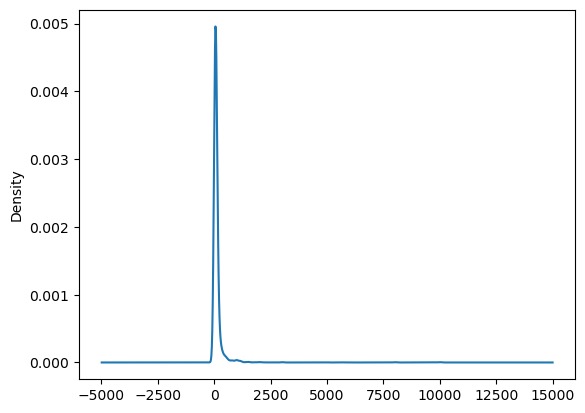

Revisión de máximos

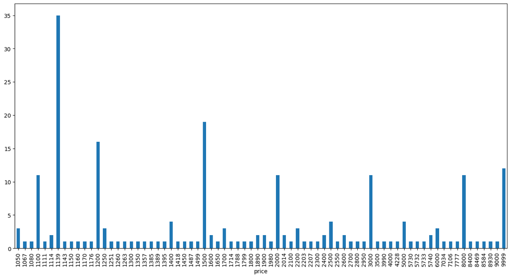

Conclusión:

el valor 9999 normalmente suele ser una forma de imputar nulos, pero en este caso su frecuencia no está muy lejos de otros valores que pueden ser válidos, como el 8000, así que no se va a tocar.

Se revisan los valores cercanos a cero

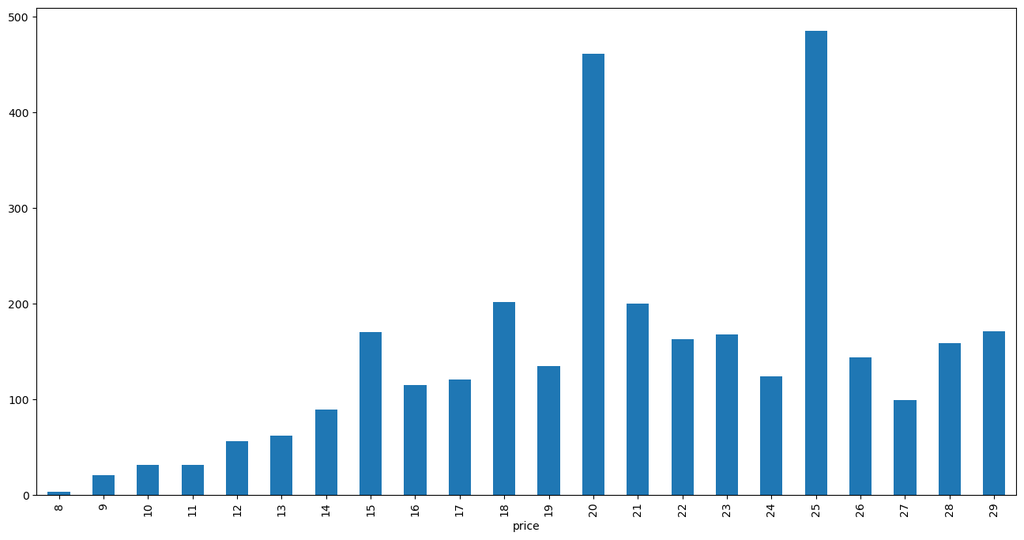

Conclusión:

Hay un pico en 20 euros, y al parecer por debajo de esa cantidad sería difícil obtener rentabilidad, así que se descartarán los inmuebles que se alquilan por debajo de 20 euros.

|  | id | name | host_id | neighbourhood_group | neighbourhood | latitude | longitude | room_type | price | minimum_nights | calculated_host_listings_count | availability_365 |
| --- | --- | --- | --- | --- | --- | --- | --- | --- | --- | --- | --- | --- |
| 0 | 6369 | Rooftop terrace room , ensuite bathroom | 13660 | Chamartín | Hispanoamérica | 40.457240 | -3.676880 | Private room | 60 | 1 | 2 | 180 |
| 1 | 21853 | Bright and airy room | 83531 | Latina | Cármenes | 40.403810 | -3.741300 | Private room | 31 | 4 | 2 | 364 |
| 2 | 23001 | Apartmento Arganzuela- Madrid Rio | 82175 | Arganzuela | Legazpi | 40.388400 | -3.695110 | Entire home/apt | 50 | 15 | 5 | 222 |
| 3 | 24805 | Gran Via Studio Madrid | 346366726 | Centro | Universidad | 40.421830 | -3.705290 | Entire home/apt | 92 | 5 | 1 | 115 |
| 4 | 26825 | Single Room whith private Bathroom | 114340 | Arganzuela | Legazpi | 40.389750 | -3.690180 | Private room | 26 | 2 | 1 | 349 |
| ... | ... | ... | ... | ... | ... | ... | ... | ... | ... | ... | ... | ... |
| 18904 | 52182264 | Enormous Private Room in 12-Bedroom Unit - los... | 378060726 | Centro | Justicia | 40.424384 | -3.691216 | Private room | 29 | 1 | 87 | 358 |
| 18905 | 52182273 | Stunning Private Room in 11-Bedroom Unit - los... | 378060726 | Centro | Justicia | 40.424447 | -3.691309 | Private room | 29 | 1 | 87 | 358 |
| 18906 | 52182303 | Classic Private Room in 7-Bedroom Unit - los 3... | 378060726 | Centro | Justicia | 40.424989 | -3.691783 | Private room | 29 | 1 | 87 | 358 |
| 18907 | 52182321 | Elegant Private Room in 12-Bedroom Unit - los ... | 378060726 | Salamanca | Recoletos | 40.424352 | -3.690211 | Private room | 29 | 1 | 87 | 358 |
| 18908 | 52182334 | Fashioned Private Room in 12-Bedroom Unit - lo... | 378060726 | Centro | Justicia | 40.425670 | -3.691727 | Private room | 33 | 1 | 87 | 358 |

17710 rows × 12 columns

Para minimum_nights y calculated_host_listings_count habría que hacer un ejercicio similar.

No obstante, por el momento no hace parte del core de análisis.

### Tabla Listings_det

#### Visión general

|  | index | id | listing_url | scrape_id | last_scraped | name | description | neighborhood_overview | picture_url | host_id | host_url | host_name | host_since | host_location | host_about | host_response_time | host_response_rate | host_acceptance_rate | host_is_superhost | host_thumbnail_url | host_picture_url | host_neighbourhood | host_listings_count | host_total_listings_count | host_verifications | host_has_profile_pic | host_identity_verified | neighbourhood | neighbourhood_cleansed | … |
| --- | --- | --- | --- | --- | --- | --- | --- | --- | --- | --- | --- | --- | --- | --- | --- | --- | --- | --- | --- | --- | --- | --- | --- | --- | --- | --- | --- | --- | --- | --- |
| 0 | 0 | 6369 | https://www.airbnb.com/rooms/6369 | 20210910193531 | 2021-09-11 | Rooftop terrace room , ensuite bathroom | Excellent connection with the AIRPORT and EXHI... | None | https://a0.muscache.com/pictures/683224/4cc318... | 13660 | https://www.airbnb.com/users/show/13660 | Simon | 2009-04-16 | Madrid, Community of Madrid, Spain | Gay couple, heterofriendly, enjoy having guest... | within a few hours | 100% | 83% | t | https://a0.muscache.com/im/pictures/user/1c793... | https://a0.muscache.com/im/pictures/user/1c793... | Hispanoamérica | 1.0 | 1.0 | ['email', 'phone', 'reviews', 'jumio', 'offlin... | t | t | None | Hispanoamérica | … |
| 1 | 1 | 21853 | https://www.airbnb.com/rooms/21853 | 20210910193531 | 2021-09-11 | Bright and airy room | We have a quiet and sunny room with a good vie... | We live in a leafy neighbourhood with plenty o... | https://a0.muscache.com/pictures/68483181/87bc... | 83531 | https://www.airbnb.com/users/show/83531 | Abdel | 2010-02-21 | Madrid, Madrid, Spain | EN-ES-FR\r\nEN\r\nHi everybody: I'm Abdel. I'm... | None | None | None | f | https://a0.muscache.com/im/users/83531/profile... | https://a0.muscache.com/im/users/83531/profile... | Aluche | 2.0 | 2.0 | ['email', 'phone', 'reviews', 'manual_offline'... | t | t | Madrid, Spain | Cármenes | … |
| 2 | 2 | 23001 | https://www.airbnb.com/rooms/23001 | 20210910193531 | 2021-09-11 | Apartmento Arganzuela- Madrid Rio | Apartamento de tres dormitorios dobles, gran s... | Barrio Arganzuela, junto a Madrid Rio, zonas c... | https://a0.muscache.com/pictures/58e6a770-509c... | 82175 | https://www.airbnb.com/users/show/82175 | Jesus | 2010-02-17 | Madrid, Community of Madrid, Spain | Hi,\r\n\r\nWelcome to my apartments in the dow... | within a few hours | 97% | 64% | f | https://a0.muscache.com/im/pictures/user/52bdf... | https://a0.muscache.com/im/pictures/user/52bdf... | Legazpi | 10.0 | 10.0 | ['email', 'phone', 'reviews', 'jumio', 'offlin... | t | t | Madrid, Comunidad de Madrid, Spain | Legazpi | … |
| 3 | 3 | 24805 | https://www.airbnb.com/rooms/24805 | 20210910193531 | 2021-09-11 | Gran Via Studio Madrid | Studio located 50 meters from Gran Via, next t... | The area is next to the Gran Via, so people li... | https://a0.muscache.com/pictures/miso/Hosting-... | 346366726 | https://www.airbnb.com/users/show/346366726 | A | 2020-05-15 | ES | None | None | None | None | f | https://a0.muscache.com/im/pictures/user/d3167... | https://a0.muscache.com/im/pictures/user/d3167... | None | 1.0 | 1.0 | ['email', 'phone'] | t | f | Madrid, Spain | Universidad | … |
| 4 | 4 | 26825 | https://www.airbnb.com/rooms/26825 | 20210910193531 | 2021-09-11 | Single Room whith private Bathroom | Nice and cozy roon for one person with a priva... | Es un barrio muy tranquilo, en una zona de Mad... | https://a0.muscache.com/pictures/149358/218d5b... | 114340 | https://www.airbnb.com/users/show/114340 | Agustina | 2010-04-27 | Madrid, Madrid, Spain | I like Fine art, Photography, Cinema, travel a... | within an hour | 100% | 50% | f | https://a0.muscache.com/im/users/114340/profil... | https://a0.muscache.com/im/users/114340/profil... | Legazpi | 1.0 | 1.0 | ['email', 'phone', 'reviews', 'jumio', 'govern... | t | t | Madrid, Comunidad de Madrid, Spain | Legazpi | … |

```
<class 'pandas.core.frame.DataFrame'>
RangeIndex: 18909 entries, 0 to 18908
Data columns (total 75 columns):
 #   Column                                        Non-Null Count  Dtype
---  ------                                        --------------  -----
 0   index                                         18909 non-null  int64
 1   id                                            18909 non-null  int64
 2   listing_url                                   18909 non-null  object
 3   scrape_id                                     18909 non-null  int64
 4   last_scraped                                  18909 non-null  object
 5   name                                          18906 non-null  object
 6   description                                   17854 non-null  object
 7   neighborhood_overview                         10997 non-null  object
 8   picture_url                                   18908 non-null  object
 9   host_id                                       18909 non-null  int64
```

[output cut: 67 more lines]

#### Variables y Tipos

Se seleccionan solamente aquellas variables que aportan información relevante para los objetivos.

|  | id | description | host_is_superhost | accommodates | bathrooms | bedrooms | beds | number_of_reviews | review_scores_rating | review_scores_communication | review_scores_location |
| --- | --- | --- | --- | --- | --- | --- | --- | --- | --- | --- | --- |
| 0 | 6369 | Excellent connection with the AIRPORT and EXHI... | t | 2 | NaN | 1.0 | 1.0 | 80 | 4.87 | 4.89 | 4.77 |
| 1 | 21853 | We have a quiet and sunny room with a good vie... | f | 1 | NaN | 1.0 | 1.0 | 33 | 4.58 | 4.82 | 4.21 |
| 2 | 23001 | Apartamento de tres dormitorios dobles, gran s... | f | 6 | NaN | 3.0 | 5.0 | 0 | NaN | NaN | NaN |
| 3 | 24805 | Studio located 50 meters from Gran Via, next t... | f | 3 | NaN | NaN | 1.0 | 12 | 4.92 | 5.00 | 5.00 |
| 4 | 26825 | Nice and cozy roon for one person with a priva... | f | 1 | NaN | 1.0 | 1.0 | 149 | 4.68 | 4.71 | 4.70 |
| ... | ... | ... | ... | ... | ... | ... | ... | ... | ... | ... | ... |
| 18904 | 52182264 | ROOM - 8 sqm. • 1st Floor <br /> <br />cozy ro... | f | 1 | NaN | 1.0 | 0.0 | 0 | NaN | NaN | NaN |
| 18905 | 52182273 | ROOM - 10 sqm. • 4th Floor <br /> <br />cozy r... | f | 1 | NaN | 1.0 | 0.0 | 0 | NaN | NaN | NaN |
| 18906 | 52182303 | ROOM <br /> <br />cozy room in madrid centro i... | f | 1 | NaN | 1.0 | 0.0 | 0 | NaN | NaN | NaN |
| 18907 | 52182321 | ROOM -9 sqm. • 1st Floor <br /> <br />cozy roo... | f | 1 | NaN | 1.0 | 0.0 | 0 | NaN | NaN | NaN |
| 18908 | 52182334 | ROOM - 10 sqm. • 1st Floor <br /> <br />cozy r... | f | 1 | NaN | 1.0 | 0.0 | 0 | NaN | NaN | NaN |

18909 rows × 11 columns

### Análisis de Tipos

```
<class 'pandas.core.frame.DataFrame'>
RangeIndex: 18909 entries, 0 to 18908
Data columns (total 11 columns):
 #   Column                       Non-Null Count  Dtype
---  ------                       --------------  -----
 0   id                           18909 non-null  int64
 1   description                  17854 non-null  object
 2   host_is_superhost            18883 non-null  object
 3   accommodates                 18909 non-null  int64
 4   bathrooms                    0 non-null      float64
 5   bedrooms                     17475 non-null  float64
 6   beds                         18568 non-null  float64
 7   number_of_reviews            18909 non-null  int64
 8   review_scores_rating         13877 non-null  float64
 9   review_scores_communication  13640 non-null  float64
 10  review_scores_location       13637 non-null  float64
dtypes: float64(6), int64(3), object(2)
memory usage: 1.6+ MB
```

Conclusión: Pasar host_is_superhost a categórica

```
<class 'pandas.core.frame.DataFrame'>
RangeIndex: 18909 entries, 0 to 18908
Data columns (total 11 columns):
 #   Column                       Non-Null Count  Dtype
---  ------                       --------------  -----
 0   id                           18909 non-null  int64
 1   description                  17854 non-null  object
 2   host_is_superhost            18883 non-null  category
 3   accommodates                 18909 non-null  int64
 4   bathrooms                    0 non-null      float64
 5   bedrooms                     17475 non-null  float64
 6   beds                         18568 non-null  float64
 7   number_of_reviews            18909 non-null  int64
 8   review_scores_rating         13877 non-null  float64
 9   review_scores_communication  13640 non-null  float64
 10  review_scores_location       13637 non-null  float64
dtypes: category(1), float64(6), int64(3), object(1)
memory usage: 1.5+ MB
```

### Análisis de Nulos

```
id                                 0
description                     1055
host_is_superhost                 26
accommodates                       0
bathrooms                      18909
bedrooms                        1434
beds                             341
number_of_reviews                  0
review_scores_rating            5032
review_scores_communication     5269
review_scores_location          5272
dtype: int64
```

Conclusiones:

- bathrooms: está totalmente a nulos, por tanto se elimina.
- description: no hay problema porque tenga nulos, así que se conserva.
- host_is_superhost: tiene muy pocos nulos y no es una variable muy relevante, así que se conserva.
- beds: es posible intentar imputarla a partir de accomodates.
- bedrooms: si es una variable importante, es posible intentar imputar los nulos a través de proxies como accomodates o beds.

Se evalua la posibilidad de hacer una imputación de beds a partir del número de personas que se pueden acomodar.

| accommodates beds | 1 | 2 | 3 | 4 | 5 | 6 | 7 | 8 | 9 | 10 | 11 | 12 | 13 | 14 | 15 | 16 |
| --- | --- | --- | --- | --- | --- | --- | --- | --- | --- | --- | --- | --- | --- | --- | --- | --- |
| 0.0 | 222 | 259 | 41 | 68 | 15 | 12 | 5 | 3 | 0 | 2 | 0 | 0 | 0 | 0 | 0 | 1 |
| 1.0 | 2765 | 4911 | 399 | 639 | 14 | 9 | 0 | 3 | 0 | 2 | 0 | 0 | 0 | 0 | 0 | 9 |
| 2.0 | 120 | 1110 | 1016 | 2277 | 125 | 148 | 3 | 3 | 0 | 1 | 0 | 0 | 1 | 0 | 0 | 1 |
| 3.0 | 18 | 75 | 231 | 925 | 395 | 582 | 18 | 26 | 1 | 1 | 0 | 0 | 0 | 0 | 0 | 0 |
| 4.0 | 20 | 28 | 32 | 216 | 214 | 498 | 73 | 92 | 3 | 9 | 0 | 1 | 0 | 0 | 0 | 0 |
| 5.0 | 2 | 5 | 6 | 20 | 42 | 178 | 75 | 94 | 9 | 30 | 2 | 2 | 0 | 1 | 0 | 0 |
| 6.0 | 14 | 9 | 2 | 5 | 7 | 62 | 21 | 61 | 9 | 18 | 4 | 8 | 2 | 0 | 0 | 0 |
| 7.0 | 0 | 1 | 0 | 2 | 2 | 6 | 10 | 19 | 8 | 17 | 2 | 6 | 1 | 4 | 0 | 0 |
| 8.0 | 3 | 2 | 0 | 0 | 3 | 2 | 0 | 21 | 3 | 18 | 2 | 9 | 2 | 2 | 1 | 0 |
| 9.0 | 0 | 0 | 0 | 0 | 1 | 1 | 0 | 0 | 0 | 6 | 2 | 8 | 1 | 0 | 0 | 1 |
| 10.0 | 10 | 2 | 1 | 1 | 2 | 0 | 0 | 0 | 0 | 7 | 0 | 2 | 1 | 0 | 4 | 9 |
| 11.0 | 0 | 0 | 0 | 0 | 0 | 0 | 0 | 1 | 0 | 0 | 0 | 0 | 1 | 1 | 0 | 3 |
| 12.0 | 1 | 0 | 0 | 0 | 0 | 0 | 0 | 1 | 0 | 0 | 0 | 1 | 0 | 0 | 1 | 1 |
| 13.0 | 0 | 0 | 0 | 0 | 0 | 0 | 0 | 0 | 0 | 0 | 0 | 0 | 0 | 1 | 1 | 2 |
| 14.0 | 0 | 0 | 0 | 0 | 0 | 0 | 0 | 0 | 0 | 0 | 0 | 0 | 0 | 1 | 0 | 5 |
| 15.0 | 0 | 0 | 0 | 0 | 0 | 0 | 0 | 0 | 0 | 0 | 0 | 0 | 0 | 0 | 0 | 1 |
| 16.0 | 0 | 0 | 0 | 0 | 0 | 0 | 0 | 0 | 0 | 0 | 0 | 0 | 0 | 0 | 0 | 5 |
| 17.0 | 0 | 0 | 0 | 0 | 0 | 0 | 0 | 0 | 0 | 0 | 0 | 0 | 0 | 0 | 0 | 2 |
| 18.0 | 0 | 0 | 0 | 0 | 0 | 1 | 0 | 0 | 0 | 0 | 0 | 0 | 0 | 0 | 0 | 1 |
| 23.0 | 0 | 0 | 0 | 0 | 0 | 0 | 0 | 0 | 0 | 0 | 0 | 0 | 0 | 0 | 0 | 1 |
| 24.0 | 0 | 1 | 0 | 0 | 0 | 0 | 0 | 0 | 0 | 0 | 0 | 0 | 0 | 0 | 0 | 0 |

Al Parecer si es posible realizar una asignación mas o menos directa. Leyendo la matriz en vertical es posible notar que:

- una o dos personas se suelen corresponder con una cama.
- tres o cuatro personas se suelen corresponder con dos camas.
- cinco o seis personas se suelen corresponder con tres camas.
- a más de 6 personas le vamos a poner cuatro camas.

Se verifica el número de nulos y la frecuencia de cada valor

```
beds
1.0     8751
2.0     4805
3.0     2272
4.0     1186
0.0      628
5.0      466
NaN      341
6.0      222
7.0       78
8.0       68
10.0      39
9.0       20
14.0       6
11.0       6
12.0       5
16.0       5
13.0       4
18.0       2
17.0       2
15.0       1
23.0       1
24.0       1
Name: count, dtype: int64
```

Se crea una función para imputar los nulos de beds con base a accommodates

Comprobación

```
beds
1.0     9061
2.0     4828
3.0     2276
4.0     1190
0.0      628
5.0      466
6.0      222
7.0       78
8.0       68
10.0      39
9.0       20
14.0       6
11.0       6
12.0       5
16.0       5
13.0       4
18.0       2
17.0       2
15.0       1
23.0       1
24.0       1
Name: count, dtype: int64
```

Se verifica la posibilidad de hacer una imputación de bedrooms.

Se inicia por cruzar el número de habitaciones con el número de personas que se pueden acomodar.

| accommodates bedrooms | 1 | 2 | 3 | 4 | 5 | 6 | 7 | 8 | 9 | 10 | 11 | 12 | 13 | 14 | 15 | 16 |
| --- | --- | --- | --- | --- | --- | --- | --- | --- | --- | --- | --- | --- | --- | --- | --- | --- |
| 1.0 | 3009 | 5569 | 1141 | 2265 | 111 | 81 | 4 | 14 | 0 | 7 | 0 | 0 | 0 | 0 | 0 | 11 |
| 2.0 | 74 | 173 | 348 | 1560 | 444 | 852 | 51 | 48 | 4 | 6 | 1 | 0 | 0 | 1 | 0 | 0 |
| 3.0 | 21 | 22 | 45 | 104 | 220 | 509 | 106 | 158 | 7 | 20 | 4 | 13 | 1 | 2 | 1 | 0 |
| 4.0 | 16 | 21 | 1 | 12 | 18 | 38 | 34 | 96 | 10 | 39 | 2 | 15 | 5 | 2 | 0 | 2 |
| 5.0 | 9 | 6 | 0 | 0 | 4 | 3 | 4 | 6 | 9 | 34 | 3 | 8 | 1 | 3 | 3 | 12 |
| 6.0 | 3 | 3 | 0 | 0 | 0 | 1 | 0 | 1 | 3 | 4 | 2 | 1 | 1 | 1 | 2 | 2 |
| 7.0 | 0 | 0 | 1 | 0 | 0 | 0 | 1 | 0 | 0 | 0 | 0 | 0 | 1 | 1 | 1 | 6 |
| 8.0 | 1 | 2 | 0 | 0 | 0 | 0 | 0 | 0 | 0 | 0 | 0 | 0 | 0 | 0 | 0 | 4 |
| 9.0 | 0 | 0 | 0 | 0 | 0 | 1 | 0 | 0 | 0 | 0 | 0 | 0 | 0 | 0 | 0 | 2 |
| 10.0 | 0 | 1 | 0 | 0 | 0 | 0 | 0 | 0 | 0 | 1 | 0 | 0 | 0 | 0 | 0 | 1 |
| 14.0 | 0 | 1 | 0 | 0 | 0 | 0 | 0 | 0 | 0 | 1 | 0 | 0 | 0 | 0 | 0 | 0 |
| 15.0 | 0 | 0 | 0 | 0 | 0 | 0 | 0 | 0 | 0 | 0 | 0 | 0 | 0 | 0 | 0 | 1 |
| 18.0 | 0 | 1 | 0 | 0 | 0 | 0 | 0 | 0 | 0 | 0 | 0 | 0 | 0 | 0 | 0 | 0 |

No parece muy fiable.

Se contrasta con el número de camas.

| beds bedrooms | 0.0 | 1.0 | 2.0 | 3.0 | 4.0 | 5.0 | 6.0 | 7.0 | 8.0 | 9.0 | 10.0 | 11.0 | 12.0 | 13.0 | 14.0 | 15.0 | 16.0 | 17.0 | 18.0 | 23.0 | 24.0 |
| --- | --- | --- | --- | --- | --- | --- | --- | --- | --- | --- | --- | --- | --- | --- | --- | --- | --- | --- | --- | --- | --- |
| 1.0 | 451 | 8038 | 3039 | 459 | 139 | 15 | 36 | 1 | 13 | 1 | 18 | 0 | 1 | 0 | 1 | 0 | 0 | 0 | 0 | 0 | 0 |
| 2.0 | 65 | 108 | 1372 | 1329 | 532 | 110 | 33 | 7 | 5 | 0 | 0 | 0 | 0 | 0 | 0 | 0 | 0 | 0 | 1 | 0 | 0 |
| 3.0 | 7 | 28 | 22 | 414 | 393 | 242 | 80 | 25 | 11 | 7 | 2 | 2 | 0 | 0 | 0 | 0 | 0 | 0 | 0 | 0 | 0 |
| 4.0 | 6 | 23 | 3 | 7 | 95 | 63 | 56 | 27 | 19 | 6 | 2 | 2 | 2 | 0 | 0 | 0 | 0 | 0 | 0 | 0 | 0 |
| 5.0 | 1 | 14 | 0 | 0 | 2 | 26 | 10 | 16 | 17 | 2 | 9 | 1 | 1 | 2 | 1 | 0 | 2 | 0 | 1 | 0 | 0 |
| 6.0 | 2 | 4 | 0 | 0 | 0 | 0 | 6 | 0 | 2 | 3 | 3 | 0 | 1 | 1 | 0 | 0 | 1 | 1 | 0 | 0 | 0 |
| 7.0 | 0 | 0 | 1 | 0 | 1 | 0 | 0 | 1 | 1 | 0 | 0 | 0 | 0 | 1 | 3 | 1 | 1 | 1 | 0 | 0 | 0 |
| 8.0 | 0 | 3 | 0 | 0 | 0 | 0 | 0 | 0 | 0 | 1 | 2 | 0 | 0 | 0 | 1 | 0 | 0 | 0 | 0 | 0 | 0 |
| 9.0 | 0 | 0 | 0 | 0 | 0 | 0 | 0 | 1 | 0 | 0 | 1 | 1 | 0 | 0 | 0 | 0 | 0 | 0 | 0 | 0 | 0 |
| 10.0 | 0 | 0 | 0 | 0 | 0 | 0 | 0 | 0 | 0 | 0 | 2 | 0 | 0 | 0 | 0 | 0 | 1 | 0 | 0 | 0 | 0 |
| 14.0 | 1 | 0 | 0 | 0 | 0 | 0 | 0 | 0 | 0 | 0 | 0 | 0 | 0 | 0 | 0 | 0 | 0 | 0 | 0 | 0 | 1 |
| 15.0 | 0 | 0 | 0 | 0 | 0 | 0 | 0 | 0 | 0 | 0 | 0 | 0 | 0 | 0 | 0 | 0 | 0 | 0 | 0 | 1 | 0 |
| 18.0 | 0 | 1 | 0 | 0 | 0 | 0 | 0 | 0 | 0 | 0 | 0 | 0 | 0 | 0 | 0 | 0 | 0 | 0 | 0 | 0 | 0 |

Aquí si es posible realizar una asignación más directa. Leyendo la matriz en vertical se evidencia que:

- cero, una o dos camas se suele corresponder con una habitación.
- tres o cuatro camas se suele corresponder con dos habitaciones.
- cinco o seis camas se suele corresponder con tres habitaciones.
- a más camas se le asignaran cuatro habitaciones.

Se modifica la función que creada pasos atrás para imputar los nulos de bedrooms a partir de beds.

Primero se realiza el conteo de bedrooms.

```
bedrooms
1.0     12212
2.0      3562
NaN      1434
3.0      1233
4.0       311
5.0       105
6.0        24
7.0        11
8.0         7
9.0         3
10.0        3
14.0        2
15.0        1
18.0        1
Name: count, dtype: int64
```

Se ejecuta la función actualizada

Comprobación

```
bedrooms
1.0     13540
2.0      3657
3.0      1244
4.0       311
5.0       105
6.0        24
7.0        11
8.0         7
9.0         3
10.0        3
14.0        2
15.0        1
18.0        1
Name: count, dtype: int64
```

Se elimina bathrooms, variable NO relevante

|  | id | description | host_is_superhost | accommodates | bedrooms | beds | number_of_reviews | review_scores_rating | review_scores_communication | review_scores_location |
| --- | --- | --- | --- | --- | --- | --- | --- | --- | --- | --- |
| 0 | 6369 | Excellent connection with the AIRPORT and EXHI... | t | 2 | 1.0 | 1.0 | 80 | 4.87 | 4.89 | 4.77 |
| 1 | 21853 | We have a quiet and sunny room with a good vie... | f | 1 | 1.0 | 1.0 | 33 | 4.58 | 4.82 | 4.21 |
| 2 | 23001 | Apartamento de tres dormitorios dobles, gran s... | f | 6 | 3.0 | 5.0 | 0 | NaN | NaN | NaN |
| 3 | 24805 | Studio located 50 meters from Gran Via, next t... | f | 3 | 1.0 | 1.0 | 12 | 4.92 | 5.00 | 5.00 |
| 4 | 26825 | Nice and cozy roon for one person with a priva... | f | 1 | 1.0 | 1.0 | 149 | 4.68 | 4.71 | 4.70 |
| ... | ... | ... | ... | ... | ... | ... | ... | ... | ... | ... |
| 18904 | 52182264 | ROOM - 8 sqm. • 1st Floor <br /> <br />cozy ro... | f | 1 | 1.0 | 0.0 | 0 | NaN | NaN | NaN |
| 18905 | 52182273 | ROOM - 10 sqm. • 4th Floor <br /> <br />cozy r... | f | 1 | 1.0 | 0.0 | 0 | NaN | NaN | NaN |
| 18906 | 52182303 | ROOM <br /> <br />cozy room in madrid centro i... | f | 1 | 1.0 | 0.0 | 0 | NaN | NaN | NaN |
| 18907 | 52182321 | ROOM -9 sqm. • 1st Floor <br /> <br />cozy roo... | f | 1 | 1.0 | 0.0 | 0 | NaN | NaN | NaN |
| 18908 | 52182334 | ROOM - 10 sqm. • 1st Floor <br /> <br />cozy r... | f | 1 | 1.0 | 0.0 | 0 | NaN | NaN | NaN |

18909 rows × 10 columns

### Análisis de Duplicados

Se comprueba si existen registros duplicados

```
0
```

```
<class 'pandas.core.frame.DataFrame'>
RangeIndex: 18909 entries, 0 to 18908
Data columns (total 10 columns):
 #   Column                       Non-Null Count  Dtype
---  ------                       --------------  -----
 0   id                           18909 non-null  int64
 1   description                  17854 non-null  object
 2   host_is_superhost            18883 non-null  category
 3   accommodates                 18909 non-null  int64
 4   bedrooms                     18909 non-null  float64
 5   beds                         18909 non-null  float64
 6   number_of_reviews            18909 non-null  int64
 7   review_scores_rating         13877 non-null  float64
 8   review_scores_communication  13640 non-null  float64
 9   review_scores_location       13637 non-null  float64
dtypes: category(1), float64(5), int64(3), object(1)
memory usage: 1.3+ MB
```

### Análisis de Variables Categóricas

Análisis de valores y frecuencias de las variables categóricas

```
host_is_superhost
f    15423
t     3460
Name: count, dtype: int64
```

### Análisis de Variables Numéricas

|  | count | mean | std | min | 25% | 50% | 75% | max |
| --- | --- | --- | --- | --- | --- | --- | --- | --- |
| id | 18909.0 | 3.055841e+07 | 1.448889e+07 | 6369.0 | 19305558.00 | 33537761.00 | 42555334.00 | 52182334.0 |
| accommodates | 18909.0 | 3.094928e+00 | 1.963715e+00 | 0.0 | 2.00 | 2.00 | 4.00 | 16.0 |
| bedrooms | 18909.0 | 1.414670e+00 | 8.116969e-01 | 1.0 | 1.00 | 1.00 | 2.00 | 18.0 |
| beds | 18909.0 | 1.909197e+00 | 1.444317e+00 | 0.0 | 1.00 | 1.00 | 2.00 | 24.0 |
| number_of_reviews | 18909.0 | 3.270612e+01 | 6.524996e+01 | 0.0 | 0.00 | 5.00 | 32.00 | 744.0 |
| review_scores_rating | 13877.0 | 4.549404e+00 | 7.834379e-01 | 0.0 | 4.50 | 4.75 | 4.94 | 5.0 |
| review_scores_communication | 13640.0 | 4.776612e+00 | 4.632929e-01 | 1.0 | 4.75 | 4.92 | 5.00 | 5.0 |
| review_scores_location | 13637.0 | 4.788151e+00 | 3.774844e-01 | 1.0 | 4.73 | 4.92 | 5.00 | 5.0 |

No se eviencia nada anormal

Hasta este punto ya se han detectado y corregido los principales problemas de calidad de datos, así que se procede a crear el datamart analítico mediante la integración de las tablas.

## DATAMART ANALÍTICO

Se tienen 2 tablas principales:

- listings
- listings_det

Y es conocido que ambas comparten el campo id, por tanto, es posible cruzarlas por dicho campo.

La tabla principal es listings, ya que la de detalle lo que hace es darnos datos adicionales.

Es decir, la tabla principal en la integración es listings.

Además también se tiene la tabla del precio, que para el caso se cruzará conceptualmente con listings a través del distrito (neighbourhood_group).

Aunque aún no se ha comprobado que los literales sean iguales, por tanto, quizá será necesario hacer alguna corrección manual.

```
(17710, 12)
```

```
(18909, 10)
```

De acuerdo con lo consignado anteriormente, si todo es correcto, la tabla final tendrá 17710 filas y 21 columnas

|  | id | name | host_id | neighbourhood_group | neighbourhood | latitude | longitude | room_type | price | minimum_nights | calculated_host_listings_count | availability_365 | description | host_is_superhost | accommodates | bedrooms | beds | number_of_reviews | review_scores_rating | review_scores_communication | review_scores_location |
| --- | --- | --- | --- | --- | --- | --- | --- | --- | --- | --- | --- | --- | --- | --- | --- | --- | --- | --- | --- | --- | --- |
| 0 | 6369 | Rooftop terrace room , ensuite bathroom | 13660 | Chamartín | Hispanoamérica | 40.457240 | -3.676880 | Private room | 60 | 1 | 2 | 180 | Excellent connection with the AIRPORT and EXHI... | t | 2 | 1.0 | 1.0 | 80 | 4.87 | 4.89 | 4.77 |
| 1 | 21853 | Bright and airy room | 83531 | Latina | Cármenes | 40.403810 | -3.741300 | Private room | 31 | 4 | 2 | 364 | We have a quiet and sunny room with a good vie... | f | 1 | 1.0 | 1.0 | 33 | 4.58 | 4.82 | 4.21 |
| 2 | 23001 | Apartmento Arganzuela- Madrid Rio | 82175 | Arganzuela | Legazpi | 40.388400 | -3.695110 | Entire home/apt | 50 | 15 | 5 | 222 | Apartamento de tres dormitorios dobles, gran s... | f | 6 | 3.0 | 5.0 | 0 | NaN | NaN | NaN |
| 3 | 24805 | Gran Via Studio Madrid | 346366726 | Centro | Universidad | 40.421830 | -3.705290 | Entire home/apt | 92 | 5 | 1 | 115 | Studio located 50 meters from Gran Via, next t... | f | 3 | 1.0 | 1.0 | 12 | 4.92 | 5.00 | 5.00 |
| 4 | 26825 | Single Room whith private Bathroom | 114340 | Arganzuela | Legazpi | 40.389750 | -3.690180 | Private room | 26 | 2 | 1 | 349 | Nice and cozy roon for one person with a priva... | f | 1 | 1.0 | 1.0 | 149 | 4.68 | 4.71 | 4.70 |
| ... | ... | ... | ... | ... | ... | ... | ... | ... | ... | ... | ... | ... | ... | ... | ... | ... | ... | ... | ... | ... | ... |
| 17705 | 52182264 | Enormous Private Room in 12-Bedroom Unit - los... | 378060726 | Centro | Justicia | 40.424384 | -3.691216 | Private room | 29 | 1 | 87 | 358 | ROOM - 8 sqm. • 1st Floor <br /> <br />cozy ro... | f | 1 | 1.0 | 0.0 | 0 | NaN | NaN | NaN |
| 17706 | 52182273 | Stunning Private Room in 11-Bedroom Unit - los... | 378060726 | Centro | Justicia | 40.424447 | -3.691309 | Private room | 29 | 1 | 87 | 358 | ROOM - 10 sqm. • 4th Floor <br /> <br />cozy r... | f | 1 | 1.0 | 0.0 | 0 | NaN | NaN | NaN |
| 17707 | 52182303 | Classic Private Room in 7-Bedroom Unit - los 3... | 378060726 | Centro | Justicia | 40.424989 | -3.691783 | Private room | 29 | 1 | 87 | 358 | ROOM <br /> <br />cozy room in madrid centro i... | f | 1 | 1.0 | 0.0 | 0 | NaN | NaN | NaN |
| 17708 | 52182321 | Elegant Private Room in 12-Bedroom Unit - los ... | 378060726 | Salamanca | Recoletos | 40.424352 | -3.690211 | Private room | 29 | 1 | 87 | 358 | ROOM -9 sqm. • 1st Floor <br /> <br />cozy roo... | f | 1 | 1.0 | 0.0 | 0 | NaN | NaN | NaN |
| 17709 | 52182334 | Fashioned Private Room in 12-Bedroom Unit - lo... | 378060726 | Centro | Justicia | 40.425670 | -3.691727 | Private room | 33 | 1 | 87 | 358 | ROOM - 10 sqm. • 1st Floor <br /> <br />cozy r... | f | 1 | 1.0 | 0.0 | 0 | NaN | NaN | NaN |

17710 rows × 21 columns

Ahora se analiza la posibilidad de incorporar la información externa del precio por metro cuadrado.

Para ello, lo primero es analizar los valores de la variable distrito en ambas tablas, ya que necesitan coincidir para poder cruzarlas.

```
0                Arganzuela
1                   Barajas
2               Carabanchel
3                    Centro
4                 Chamartín
5                  Chamberí
6             Ciudad Lineal
7     Fuencarral - El Pardo
8                 Hortaleza
9                    Latina
10        Moncloa - Aravaca
11                Moratalaz
12       Puente de Vallecas
13                   Retiro
14                Salamanca
15    San Blas - Canillejas
16                   Tetuán
17                    Usera
18                Vicálvaro
19        Villa de Vallecas
20               Villaverde
dtype: object
```

```
1             Arganzuela
2                Barajas
3            Carabanchel
4                 Centro
5              Chamartín
6               Chamberí
7          Ciudad Lineal
8             Fuencarral
9              Hortaleza
10                Latina
11               Moncloa
12             Moratalaz
13    Puente de Vallecas
14                Retiro
15             Salamanca
16              San Blas
17                Tetuán
18                 Usera
19             Vicálvaro
20     Villa de Vallecas
21            Villaverde
Name: distrito, dtype: object
```

Comparando, parece todo igual excepto:

- Fuencarral - El Pardo
- Moncloa - Aravaca
- San Blas - Canillejas

Por tanto, se reemplazan estos valores en precio_m2 para que sean iguales a los de df y hacer posible el cruce

|  | precio_m2 | distrito |
| --- | --- | --- |
| 1 | 4085 | Arganzuela |
| 2 | 3409 | Barajas |
| 3 | 2123 | Carabanchel |
| 4 | 4827 | Centro |
| 5 | 5098 | Chamartín |
| 6 | 5381 | Chamberí |
| 7 | 2940 | Ciudad Lineal |
| 8 | 3568 | Fuencarral - El Pardo |
| 9 | 3871 | Hortaleza |
| 10 | 2267 | Latina |
| 11 | 4033 | Moncloa - Aravaca |
| 12 | 2500 | Moratalaz |
| 13 | 1918 | Puente de Vallecas |
| 14 | 4788 | Retiro |
| 15 | 6114 | Salamanca |
| 16 | 2591 | San Blas - Canillejas |
| 17 | 3678 | Tetuán |
| 18 | 1995 | Usera |
| 19 | 2403 | Vicálvaro |
| 20 | 2354 | Villa de Vallecas |
| 21 | 1693 | Villaverde |

En este momento ya es posible cruzarlos.

Principal df.

|  | id | name | host_id | neighbourhood_group | neighbourhood | latitude | longitude | room_type | price | minimum_nights | calculated_host_listings_count | availability_365 | description | host_is_superhost | accommodates | bedrooms | beds | number_of_reviews | review_scores_rating | review_scores_communication | review_scores_location | precio_m2 | distrito |
| --- | --- | --- | --- | --- | --- | --- | --- | --- | --- | --- | --- | --- | --- | --- | --- | --- | --- | --- | --- | --- | --- | --- | --- |
| 0 | 6369 | Rooftop terrace room , ensuite bathroom | 13660 | Chamartín | Hispanoamérica | 40.457240 | -3.676880 | Private room | 60 | 1 | 2 | 180 | Excellent connection with the AIRPORT and EXHI... | t | 2 | 1.0 | 1.0 | 80 | 4.87 | 4.89 | 4.77 | 5098 | Chamartín |
| 1 | 21853 | Bright and airy room | 83531 | Latina | Cármenes | 40.403810 | -3.741300 | Private room | 31 | 4 | 2 | 364 | We have a quiet and sunny room with a good vie... | f | 1 | 1.0 | 1.0 | 33 | 4.58 | 4.82 | 4.21 | 2267 | Latina |
| 2 | 23001 | Apartmento Arganzuela- Madrid Rio | 82175 | Arganzuela | Legazpi | 40.388400 | -3.695110 | Entire home/apt | 50 | 15 | 5 | 222 | Apartamento de tres dormitorios dobles, gran s... | f | 6 | 3.0 | 5.0 | 0 | NaN | NaN | NaN | 4085 | Arganzuela |
| 3 | 24805 | Gran Via Studio Madrid | 346366726 | Centro | Universidad | 40.421830 | -3.705290 | Entire home/apt | 92 | 5 | 1 | 115 | Studio located 50 meters from Gran Via, next t... | f | 3 | 1.0 | 1.0 | 12 | 4.92 | 5.00 | 5.00 | 4827 | Centro |
| 4 | 26825 | Single Room whith private Bathroom | 114340 | Arganzuela | Legazpi | 40.389750 | -3.690180 | Private room | 26 | 2 | 1 | 349 | Nice and cozy roon for one person with a priva... | f | 1 | 1.0 | 1.0 | 149 | 4.68 | 4.71 | 4.70 | 4085 | Arganzuela |
| ... | ... | ... | ... | ... | ... | ... | ... | ... | ... | ... | ... | ... | ... | ... | ... | ... | ... | ... | ... | ... | ... | ... | ... |
| 17705 | 52182264 | Enormous Private Room in 12-Bedroom Unit - los... | 378060726 | Centro | Justicia | 40.424384 | -3.691216 | Private room | 29 | 1 | 87 | 358 | ROOM - 8 sqm. • 1st Floor <br /> <br />cozy ro... | f | 1 | 1.0 | 0.0 | 0 | NaN | NaN | NaN | 4827 | Centro |
| 17706 | 52182273 | Stunning Private Room in 11-Bedroom Unit - los... | 378060726 | Centro | Justicia | 40.424447 | -3.691309 | Private room | 29 | 1 | 87 | 358 | ROOM - 10 sqm. • 4th Floor <br /> <br />cozy r... | f | 1 | 1.0 | 0.0 | 0 | NaN | NaN | NaN | 4827 | Centro |
| 17707 | 52182303 | Classic Private Room in 7-Bedroom Unit - los 3... | 378060726 | Centro | Justicia | 40.424989 | -3.691783 | Private room | 29 | 1 | 87 | 358 | ROOM <br /> <br />cozy room in madrid centro i... | f | 1 | 1.0 | 0.0 | 0 | NaN | NaN | NaN | 4827 | Centro |
| 17708 | 52182321 | Elegant Private Room in 12-Bedroom Unit - los ... | 378060726 | Salamanca | Recoletos | 40.424352 | -3.690211 | Private room | 29 | 1 | 87 | 358 | ROOM -9 sqm. • 1st Floor <br /> <br />cozy roo... | f | 1 | 1.0 | 0.0 | 0 | NaN | NaN | NaN | 6114 | Salamanca |
| 17709 | 52182334 | Fashioned Private Room in 12-Bedroom Unit - lo... | 378060726 | Centro | Justicia | 40.425670 | -3.691727 | Private room | 33 | 1 | 87 | 358 | ROOM - 10 sqm. • 1st Floor <br /> <br />cozy r... | f | 1 | 1.0 | 0.0 | 0 | NaN | NaN | NaN | 4827 | Centro |

17710 rows × 23 columns

Se comprueba que no se hayan generado valores nulos, posiblemente originados en la unión.

```
0
```

## Almacenamiento en la Base de Datos

Ahora que ya se dispone del tablón de análisis, se guarda en la base de datos para accederlo cada vez que se requiera y no sea necesario repetir todo el procesamiento.

```
17710
```

## PREPARACIÓN DE LOS DATOS

En esta fase se crearán nuevas variables o se transformarán las existentes para poder dar mejor respuesta al objetivo.

Se usarán las variables internas, igualmente se enriquecerá el análisis con variables externas.

### Carga de Datos

|  | index | id | name | host_id | neighbourhood_group | neighbourhood | latitude | longitude | room_type | price | minimum_nights | calculated_host_listings_count | availability_365 | description | host_is_superhost | accommodates | bedrooms | beds | number_of_reviews | review_scores_rating | review_scores_communication | review_scores_location | precio_m2 | distrito |
| --- | --- | --- | --- | --- | --- | --- | --- | --- | --- | --- | --- | --- | --- | --- | --- | --- | --- | --- | --- | --- | --- | --- | --- | --- |
| 0 | 0 | 6369 | Rooftop terrace room , ensuite bathroom | 13660 | Chamartín | Hispanoamérica | 40.45724 | -3.67688 | Private room | 60 | 1 | 2 | 180 | Excellent connection with the AIRPORT and EXHI... | t | 2 | 1.0 | 1.0 | 80 | 4.87 | 4.89 | 4.77 | 5098 | Chamartín |
| 1 | 1 | 21853 | Bright and airy room | 83531 | Latina | Cármenes | 40.40381 | -3.74130 | Private room | 31 | 4 | 2 | 364 | We have a quiet and sunny room with a good vie... | f | 1 | 1.0 | 1.0 | 33 | 4.58 | 4.82 | 4.21 | 2267 | Latina |
| 2 | 2 | 23001 | Apartmento Arganzuela- Madrid Rio | 82175 | Arganzuela | Legazpi | 40.38840 | -3.69511 | Entire home/apt | 50 | 15 | 5 | 222 | Apartamento de tres dormitorios dobles, gran s... | f | 6 | 3.0 | 5.0 | 0 | NaN | NaN | NaN | 4085 | Arganzuela |
| 3 | 3 | 24805 | Gran Via Studio Madrid | 346366726 | Centro | Universidad | 40.42183 | -3.70529 | Entire home/apt | 92 | 5 | 1 | 115 | Studio located 50 meters from Gran Via, next t... | f | 3 | 1.0 | 1.0 | 12 | 4.92 | 5.00 | 5.00 | 4827 | Centro |
| 4 | 4 | 26825 | Single Room whith private Bathroom | 114340 | Arganzuela | Legazpi | 40.38975 | -3.69018 | Private room | 26 | 2 | 1 | 349 | Nice and cozy roon for one person with a priva... | f | 1 | 1.0 | 1.0 | 149 | 4.68 | 4.71 | 4.70 | 4085 | Arganzuela |

## Preparación de Variables

### Creación de KPI's de Palancas

Primero se crean las variables de análisis, es decir, las que fueron identificadas como los KPI's que serán usados en las palancas que influyen sobre el negocio.

Se dijo que son 3:

- precio por noche: esta ya se encuentra directamente en la variable price, pero se revisa para evidenciar que la entendemos bien.
- ocupación: se tiene availability_365 pero es necesario transformarla.
- precio del inmueble: esta tendrá que ser creada con variables externas así que se trabajará más adelante.

**Se inicia con el precio**

La documentación no aclara si el precio es por todo el inmueble, o si en el caso que se alquile una habitación es por habitación.

Es un dato clave para poder hacer la valoración de los potenciales ingresos de un inmueble.

Se intentará entender mediante el análisis del precio medio por tipo de alquiler.

Es importante filtrar solamente por un distrito para no incluir el efecto "zona".

Así que primero se elige un distrito que tenga muchos datos.

```
distrito
Centro                   8127
Salamanca                1218
Chamberí                 1089
Arganzuela               1005
Tetuán                    762
Retiro                    618
Carabanchel               581
Chamartín                 538
Ciudad Lineal             532
Moncloa - Aravaca         493
Puente de Vallecas        465
San Blas - Canillejas     463
Latina                    455
Hortaleza                 354
Fuencarral - El Pardo     265
Usera                     233
Barajas                   142
Villaverde                129
Moratalaz                  94
Villa de Vallecas          90
Vicálvaro                  57
Name: count, dtype: int64
```

```
room_type
Entire home/apt    148.859980
Private room        67.131643
Shared room         60.464286
Name: price, dtype: float64
```

Conclusiones:

- alquilar el apartamento tiene un precio medio de 148€.
- alquilar una habitación tiene un precio medio de 60€ o 67€ según sea compartida o privada.
- por tanto, para calcular los "ingresos" de un inmueble se deberá multiplicar el precio por el número de habitaciones cuando sea de los tipos Private room o Shared room.

Ahora bien, multiplicar el precio por el total de habitaciones puede sesgar artificialmente al alza la capacidad de generar ingresos de un inmueble.

Ya que si se alquila por habitaciones no es probable que siempre esté al 100%.

Por tanto, se debe ponderar por el porcentaje medio de habitaciones alquiladas.

No se dispone de ese dato, pero se supone que el responsable de negocio nos ha indicado que es del 70%.

Es posible entonces crear la variable precio total.

Comprobación

|  | room_type | price | beds | precio_total |
| --- | --- | --- | --- | --- |
| 0 | Private room | 60 | 1.0 | 60.0 |
| 1 | Private room | 31 | 1.0 | 31.0 |
| 2 | Entire home/apt | 50 | 5.0 | 50.0 |
| 3 | Entire home/apt | 92 | 1.0 | 92.0 |
| 4 | Private room | 26 | 1.0 | 26.0 |
| 5 | Entire home/apt | 85 | 3.0 | 85.0 |
| 6 | Entire home/apt | 65 | 2.0 | 65.0 |
| 7 | Entire home/apt | 54 | 1.0 | 54.0 |
| 8 | Entire home/apt | 1400 | 3.0 | 1400.0 |
| 9 | Entire home/apt | 81 | 2.0 | 81.0 |
| 10 | Entire home/apt | 90 | 3.0 | 90.0 |
| 11 | Entire home/apt | 82 | 2.0 | 82.0 |
| 12 | Private room | 40 | 1.0 | 40.0 |
| 13 | Private room | 36 | 2.0 | 50.4 |
| 14 | Entire home/apt | 51 | 1.0 | 51.0 |
| 15 | Entire home/apt | 76 | 2.0 | 76.0 |
| 16 | Entire home/apt | 54 | 3.0 | 54.0 |
| 17 | Entire home/apt | 60 | 3.0 | 60.0 |
| 18 | Entire home/apt | 55 | 2.0 | 55.0 |
| 19 | Entire home/apt | 121 | 6.0 | 121.0 |
| 20 | Entire home/apt | 80 | 2.0 | 80.0 |
| 21 | Entire home/apt | 63 | 2.0 | 63.0 |
| 22 | Entire home/apt | 63 | 1.0 | 63.0 |
| 23 | Entire home/apt | 46 | 1.0 | 46.0 |
| 24 | Entire home/apt | 171 | 3.0 | 171.0 |
| 25 | Private room | 55 | 1.0 | 55.0 |
| 26 | Private room | 26 | 2.0 | 36.4 |
| 27 | Private room | 31 | 2.0 | 43.4 |
| 28 | Entire home/apt | 60 | 1.0 | 60.0 |
| 29 | Entire home/apt | 149 | 2.0 | 149.0 |

**Se continua con la ocupación**

La variable availability_365 nos permite medir esto.

Esta variable indica el número de días a un año vista que el inmueble NO está ocupado.

Por tanto, es interesante transformarla a una medida más directa de ocupación, por ejemplo el % del año que SI está ocupada.

Es posible hacerlo con una tranformación directa.

|  | index | id | name | host_id | neighbourhood_group | neighbourhood | latitude | longitude | room_type | price | minimum_nights | calculated_host_listings_count | availability_365 | description | host_is_superhost | accommodates | bedrooms | beds | number_of_reviews | review_scores_rating | review_scores_communication | review_scores_location | precio_m2 | distrito | precio_total | ocupacion |
| --- | --- | --- | --- | --- | --- | --- | --- | --- | --- | --- | --- | --- | --- | --- | --- | --- | --- | --- | --- | --- | --- | --- | --- | --- | --- | --- |
| 0 | 0 | 6369 | Rooftop terrace room , ensuite bathroom | 13660 | Chamartín | Hispanoamérica | 40.45724 | -3.67688 | Private room | 60 | 1 | 2 | 180 | Excellent connection with the AIRPORT and EXHI... | t | 2 | 1.0 | 1.0 | 80 | 4.87 | 4.89 | 4.77 | 5098 | Chamartín | 60.0 | 50 |
| 1 | 1 | 21853 | Bright and airy room | 83531 | Latina | Cármenes | 40.40381 | -3.74130 | Private room | 31 | 4 | 2 | 364 | We have a quiet and sunny room with a good vie... | f | 1 | 1.0 | 1.0 | 33 | 4.58 | 4.82 | 4.21 | 2267 | Latina | 31.0 | 0 |
| 2 | 2 | 23001 | Apartmento Arganzuela- Madrid Rio | 82175 | Arganzuela | Legazpi | 40.38840 | -3.69511 | Entire home/apt | 50 | 15 | 5 | 222 | Apartamento de tres dormitorios dobles, gran s... | f | 6 | 3.0 | 5.0 | 0 | NaN | NaN | NaN | 4085 | Arganzuela | 50.0 | 39 |
| 3 | 3 | 24805 | Gran Via Studio Madrid | 346366726 | Centro | Universidad | 40.42183 | -3.70529 | Entire home/apt | 92 | 5 | 1 | 115 | Studio located 50 meters from Gran Via, next t... | f | 3 | 1.0 | 1.0 | 12 | 4.92 | 5.00 | 5.00 | 4827 | Centro | 92.0 | 68 |
| 4 | 4 | 26825 | Single Room whith private Bathroom | 114340 | Arganzuela | Legazpi | 40.38975 | -3.69018 | Private room | 26 | 2 | 1 | 349 | Nice and cozy roon for one person with a priva... | f | 1 | 1.0 | 1.0 | 149 | 4.68 | 4.71 | 4.70 | 4085 | Arganzuela | 26.0 | 4 |

## Transformación de Variables de Análisis

Algunas de las preguntas semilla están dirigidas a comprobar cómo se comporta el precio o la ocupación según otras variables como el número de habitaciones, la media de valoraciones, etc.

Normalmente, será posible hacer mejor estos análisis si se discretiza la variable de análisis.

Para el presente caso, las candidatas para este análisis son: accommodates, bedrooms, beds y number_of_reviews.

En bedrooms tiene sentido una discretización más personalizada. En las otras se puede realizar de manera automática.

**Discretizar bedrooms**

Se evalua la distribución de los datos.

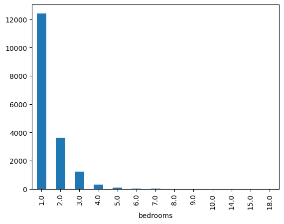

Se discretiza para 1,2,3 y más de 3.

Comprobación

```
bedrooms_disc
01_Una             12422
02_Dos              3617
03_Tres             1228
04_Cuatro o mas      443
Name: count, dtype: int64
```

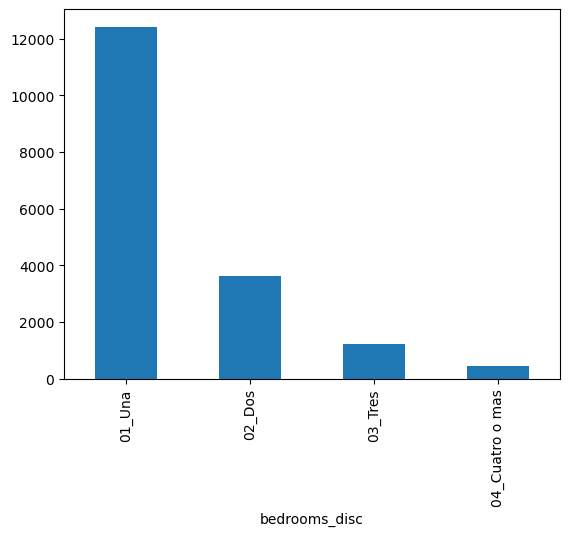

**Discretizar accommodates, beds y number_of_reviews**

Se usa qcut para discretizar con percentiles 0.5, 0.8, 1

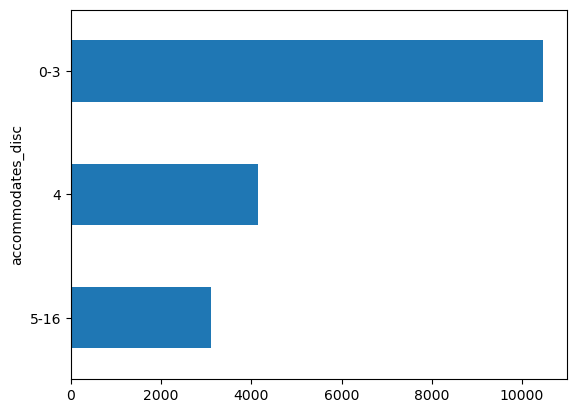

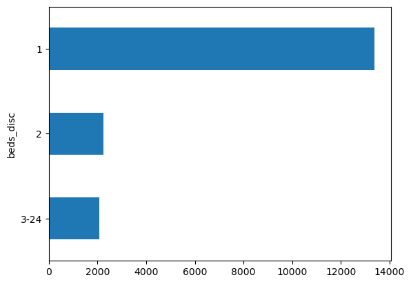

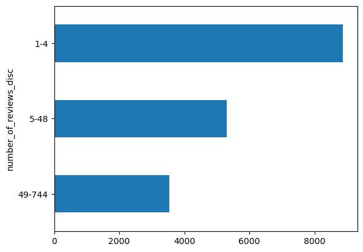

## Creación de Variables con Datos Externos

En este caso en concreto, se podrían hacer muchas cosas con datos externos.

Lo primero, que se ha incorporado parcialmente, es la palanca del precio del inmueble.

Es posible estimarla multiplicando los metros cuadrados del inmueble por el precio_m2.

El precio_m2 ya se ha conseguido, pero no se dispone del dato de tamaño del inmueble en los datos.

Es posible establecer criterios con base al número de habitaciones.

No es perfecto, pero seguramente servirá como aproximación.

**Estimación de los metros cuadrados del inmueble**

Se usará el siguiente algoritmo:

- una habitación: m2 = 50
- dos habitaciones: m2 = 70
- tres habitaciones: m2 = 90
- cuatro habitaciones: m2 = 120
- cinco o más habitaciones: m2 = 150

Comprobación

```
m2
50     12422
70      3617
90      1228
120      296
150      147
Name: count, dtype: int64
```

Ahora, ya es posible estimar el precio de compra del inmueble.

Es necesario tomar en cuenta que al precio obtenido se le sustrae un 25% por capacidad de negociación.

Comprobación

|  | bedrooms | m2 | distrito | precio_m2 | precio_compra |
| --- | --- | --- | --- | --- | --- |
| 0 | 1.0 | 50 | Chamartín | 5098 | 191175.0 |
| 1 | 1.0 | 50 | Latina | 2267 | 85012.5 |
| 2 | 3.0 | 90 | Arganzuela | 4085 | 275737.5 |
| 3 | 1.0 | 50 | Centro | 4827 | 181012.5 |
| 4 | 1.0 | 50 | Arganzuela | 4085 | 153187.5 |
| 5 | 3.0 | 90 | Arganzuela | 4085 | 275737.5 |
| 6 | 1.0 | 50 | Centro | 4827 | 181012.5 |
| 7 | 1.0 | 50 | Centro | 4827 | 181012.5 |
| 8 | 2.0 | 70 | Centro | 4827 | 253417.5 |
| 9 | 1.0 | 50 | Centro | 4827 | 181012.5 |
| 10 | 1.0 | 50 | Centro | 4827 | 181012.5 |
| 11 | 2.0 | 70 | Salamanca | 6114 | 320985.0 |
| 12 | 1.0 | 50 | Centro | 4827 | 181012.5 |
| 13 | 1.0 | 50 | Centro | 4827 | 181012.5 |
| 14 | 1.0 | 50 | Centro | 4827 | 181012.5 |
| 15 | 1.0 | 50 | Centro | 4827 | 181012.5 |
| 16 | 1.0 | 50 | Centro | 4827 | 181012.5 |
| 17 | 2.0 | 70 | Centro | 4827 | 253417.5 |
| 18 | 2.0 | 70 | Centro | 4827 | 253417.5 |
| 19 | 3.0 | 90 | Centro | 4827 | 325822.5 |

Ejemplo de qué otro tipo de variables es posible construir.

En este caso, se pueden generar variantes con las coordenadas x, y; ya que en turismo la localización es muy importante.

Por ejemplo, calcular las distancias a diferentes puntos de interés como monumentos, lugares de ocio, recintos deportivos, etc.

Simplemente, como ejemplo, se calcula la distancia de cada inmueble a la Puerta del Sol.

**Para ello se busca en Google su longitud y latitud: https://www.123coordenadas.com/coordinates/81497-puerta-del-sol-madrid**

Latitud: 40.4167278 Longitud: -3.7033387

**Cálculo de la distancia de cada inmueble a la Puerta del Sol**

Dada la curvatura de la tierra, la distancia entre dos puntos a partir de su latitud y longitud, se calcula con una fórmula que se llama distancia de Haversine.

Se crea la variable

Se comprueba revisando la distancia media por distritos.

```
distrito
Centro                    0.730611
Arganzuela                1.939114
Chamberí                  2.133167
Retiro                    2.450593
Salamanca                 2.715975
Moncloa - Aravaca         3.294526
Usera                     3.928874
Latina                    3.942634
Carabanchel               3.970238
Chamartín                 4.432842
Puente de Vallecas        4.481127
Tetuán                    4.624605
Moratalaz                 5.073901
Ciudad Lineal             5.231293
Villaverde                7.664192
Fuencarral - El Pardo     8.062301
Hortaleza                 8.074184
San Blas - Canillejas     8.199011
Vicálvaro                 8.599559
Villa de Vallecas         9.176618
Barajas                  11.439064
Name: pdi_sol, dtype: float64
```

### Se guarda en el DATAMART

Se guarda esta versión como df_preparado

```
17710
```

## ANÁLISIS E INSIGHTS

Este es el punto más importante, dónde se intentará obtener conclusiones relevantes para el objetivo utilizando todo el trabajo de preparación realizado, así como técnicas de Business Analytics.

Para ello, se empezará dando respuesta a las preguntas semilla y es probable que en el proceso vayan surgiendo hallazgos interesantes que lleven a nuevas preguntas o a la aplicación de otras técnicas.

### Carga de datos

|  | level_0 | index | id | name | host_id | neighbourhood_group | neighbourhood | latitude | longitude | room_type | price | minimum_nights | calculated_host_listings_count | availability_365 | description | host_is_superhost | accommodates | bedrooms | beds | number_of_reviews | review_scores_rating | review_scores_communication | review_scores_location | precio_m2 | distrito | precio_total | ocupacion | bedrooms_disc | accommodates_disc | … |
| --- | --- | --- | --- | --- | --- | --- | --- | --- | --- | --- | --- | --- | --- | --- | --- | --- | --- | --- | --- | --- | --- | --- | --- | --- | --- | --- | --- | --- | --- | --- |
| 0 | 0 | 0 | 6369 | Rooftop terrace room , ensuite bathroom | 13660 | Chamartín | Hispanoamérica | 40.45724 | -3.67688 | Private room | 60 | 1 | 2 | 180 | Excellent connection with the AIRPORT and EXHI... | t | 2 | 1.0 | 1.0 | 80 | 4.87 | 4.89 | 4.77 | 5098 | Chamartín | 60.0 | 50 | 01_Una | 0-3 | … |
| 1 | 1 | 1 | 21853 | Bright and airy room | 83531 | Latina | Cármenes | 40.40381 | -3.74130 | Private room | 31 | 4 | 2 | 364 | We have a quiet and sunny room with a good vie... | f | 1 | 1.0 | 1.0 | 33 | 4.58 | 4.82 | 4.21 | 2267 | Latina | 31.0 | 0 | 01_Una | 0-3 | … |
| 2 | 2 | 2 | 23001 | Apartmento Arganzuela- Madrid Rio | 82175 | Arganzuela | Legazpi | 40.38840 | -3.69511 | Entire home/apt | 50 | 15 | 5 | 222 | Apartamento de tres dormitorios dobles, gran s... | f | 6 | 3.0 | 5.0 | 0 | NaN | NaN | NaN | 4085 | Arganzuela | 50.0 | 39 | 03_Tres | 5-16 | … |
| 3 | 3 | 3 | 24805 | Gran Via Studio Madrid | 346366726 | Centro | Universidad | 40.42183 | -3.70529 | Entire home/apt | 92 | 5 | 1 | 115 | Studio located 50 meters from Gran Via, next t... | f | 3 | 1.0 | 1.0 | 12 | 4.92 | 5.00 | 5.00 | 4827 | Centro | 92.0 | 68 | 01_Una | 0-3 | … |
| 4 | 4 | 4 | 26825 | Single Room whith private Bathroom | 114340 | Arganzuela | Legazpi | 40.38975 | -3.69018 | Private room | 26 | 2 | 1 | 349 | Nice and cozy roon for one person with a priva... | f | 1 | 1.0 | 1.0 | 149 | 4.68 | 4.71 | 4.70 | 4085 | Arganzuela | 26.0 | 4 | 01_Una | 0-3 | … |

## Análisis

### Análisis sobre el precio

**¿Cuál es el precio medio? ¿y el rango de precios? ¿Y por distritos? ¿Y por barrios?**

**¿Cuál es el ranking de distritos y barrios por precio medio de alquiler?**

```
count    17710.000000
mean       149.027770
std        523.211567
min         20.000000
25%         43.000000
50%         70.000000
75%        112.000000
max      22400.000000
Name: precio_total, dtype: float64
```

Se evidencia que hay al menos un atípico por la parte de arriba que sesga la media, por tanto vamos a usar la mediana como medida de centralización más fiable.

```
70.0
```

```
distrito
San Blas - Canillejas    90.0
Salamanca                88.0
Centro                   76.0
Chamartín                74.0
Chamberí                 70.0
Hortaleza                69.0
Retiro                   68.0
Tetuán                   66.0
Moncloa - Aravaca        61.0
Fuencarral - El Pardo    60.0
Arganzuela               58.0
Vicálvaro                53.0
Ciudad Lineal            50.0
Barajas                  49.5
Carabanchel              48.0
Villa de Vallecas        47.5
Latina                   47.0
Usera                    42.0
Villaverde               42.0
Moratalaz                40.0
Puente de Vallecas       40.0
Name: precio_total, dtype: float64
```

Llama la atención el dato de San Blas, vamos a verlo con más detalle a ver qué está pasando.

|  | level_0 | index | id | name | host_id | neighbourhood_group | neighbourhood | latitude | longitude | room_type | price | minimum_nights | calculated_host_listings_count | availability_365 | description | host_is_superhost | accommodates | bedrooms | beds | number_of_reviews | review_scores_rating | review_scores_communication | review_scores_location | precio_m2 | distrito | precio_total | ocupacion | bedrooms_disc | accommodates_disc | … |
| --- | --- | --- | --- | --- | --- | --- | --- | --- | --- | --- | --- | --- | --- | --- | --- | --- | --- | --- | --- | --- | --- | --- | --- | --- | --- | --- | --- | --- | --- | --- |
| 9290 | 9290 | 9290 | 34600594 | 3 rooms near Wanda | 38951538 | San Blas - Canillejas | Arcos | 40.42105 | -3.61457 | Private room | 2800 | 1 | 2 | 0 | 3 rooms 15´walking from Wanda. | f | 6 | 3.0 | 5.0 | 0 | NaN | NaN | NaN | 2591 | San Blas - Canillejas | 9800.0 | 100 | 03_Tres | 5-16 | … |
| 9662 | 9662 | 9662 | 34826962 | Pozos rooms | 222068421 | San Blas - Canillejas | Arcos | 40.41927 | -3.61555 | Private room | 3000 | 1 | 1 | 88 | Cerca nos podemos encontrar un centro comercia... | f | 4 | 2.0 | 3.0 | 0 | NaN | NaN | NaN | 2591 | San Blas - Canillejas | 6300.0 | 75 | 02_Dos | 4 | … |
| 10189 | 10189 | 10189 | 35149419 | CHALET FOR THE FINAL CHAMPIONS LEAGUE MADRID | 143732655 | San Blas - Canillejas | Canillejas | 40.44937 | -3.61633 | Entire home/apt | 6000 | 1 | 1 | 365 | We are talking about one of the last villas fo... | f | 6 | 4.0 | 5.0 | 0 | NaN | NaN | NaN | 2591 | San Blas - Canillejas | 6000.0 | 0 | 04_Cuatro o mas | 5-16 | … |
| 9668 | 9668 | 9668 | 34833756 | Wanda Champions Final | 29628177 | San Blas - Canillejas | Rosas | 40.42622 | -3.60502 | Private room | 2700 | 1 | 1 | 0 | Somos una pareja joven educados y muy sociable... | f | 5 | 2.0 | 3.0 | 0 | NaN | NaN | NaN | 2591 | San Blas - Canillejas | 5670.0 | 100 | 02_Dos | 5-16 | … |
| 9878 | 9878 | 9878 | 34970236 | Habitaciones cerca Wanda Metropolitano (Champi... | 263474389 | San Blas - Canillejas | Arcos | 40.41920 | -3.61229 | Private room | 800 | 1 | 1 | 88 | Se alquilan 5 habitaciones, cada una para 2 hu... | f | 10 | 5.0 | 8.0 | 0 | NaN | NaN | NaN | 2591 | San Blas - Canillejas | 4480.0 | 75 | 04_Cuatro o mas | 5-16 | … |
| 9748 | 9748 | 9748 | 34882596 | 2 rooms near wanda | 38951538 | San Blas - Canillejas | Arcos | 40.41948 | -3.61427 | Private room | 1500 | 1 | 2 | 363 | 2 rooms near Wanda stadium (20' walking) with ... | f | 4 | 2.0 | 4.0 | 0 | NaN | NaN | NaN | 2591 | San Blas - Canillejas | 4200.0 | 0 | 02_Dos | 4 | … |
| 9173 | 9173 | 9173 | 34522997 | Beautiful Penthouse next to Wanda Metropolitano | 260551569 | San Blas - Canillejas | Canillejas | 40.43686 | -3.61093 | Private room | 2000 | 1 | 1 | 0 | Wonderful penthouse in a lovely duplex next to... | f | 4 | 1.0 | 3.0 | 0 | NaN | NaN | NaN | 2591 | San Blas - Canillejas | 4200.0 | 100 | 01_Una | 4 | … |
| 9831 | 9831 | 9831 | 34933116 | FINAL CHAMPIONS LEAGUE MADRID | 263232278 | San Blas - Canillejas | Simancas | 40.43968 | -3.61933 | Private room | 2000 | 2 | 1 | 365 | Near (15 minutes walking) to WANDA STADIUM.<br... | f | 5 | 3.0 | 3.0 | 0 | NaN | NaN | NaN | 2591 | San Blas - Canillejas | 4200.0 | 0 | 03_Tres | 5-16 | … |
| 10092 | 10092 | 10092 | 35091283 | FINAL CHAMPIONS LEAGUE | 264225539 | San Blas - Canillejas | Rejas | 40.44592 | -3.58746 | Private room | 1000 | 1 | 1 | 180 | Desayuno, comida y cena incluida. Traslados al... | f | 6 | 2.0 | 6.0 | 0 | NaN | NaN | NaN | 2591 | San Blas - Canillejas | 4200.0 | 50 | 02_Dos | 5-16 | … |
| 10404 | 10404 | 10404 | 35251141 | Se alquila para final de la champion league | 265376740 | San Blas - Canillejas | Canillejas | 40.44292 | -3.60764 | Entire home/apt | 3000 | 1 | 1 | 365 | None | f | 1 | 2.0 | 4.0 | 0 | NaN | NaN | NaN | 2591 | San Blas - Canillejas | 3000.0 | 0 | 02_Dos | 0-3 | … |

Se evidencia que son precios en el entorno de los 3.000 - 5.000 euros!

Al leer la descripción es posible darse cuenta que todos estos precios están definidos por la final de la Champions League.

Lo cual es un insight interesante:

*Insight 1*: pueden existir inmuebles con un valor regular residual pero, con alto valor en momentos puntuales por acontenicimientos deportivos o espectáculos.

¿Tendría sentido generar un producto de alquiler que consista en alquilar de forma "normal" a un precio inferior al mercado con la condición de que el inquilino deje el piso libre para alquilarlo "turísticamente" en fechas señaladas?

En el resto no hay sorpresas, con distritos como Salamanca, Centro o Chanmartín a la cabeza.

Pero, por ejemplo, se nota que la diferencia de precio media entre Retiro y Tetuán es muy baja.

Esto lleva a comparar el precio medio por distrito con el precio medio de compra también por distrito.

| distrito | precio_total | precio_compra |
| --- | --- | --- |
| Arganzuela | 58.0 | 153187.5 |
| Barajas | 49.5 | 127837.5 |
| Carabanchel | 48.0 | 79612.5 |
| Centro | 76.0 | 181012.5 |
| Chamartín | 74.0 | 191175.0 |
| Chamberí | 70.0 | 201787.5 |
| Ciudad Lineal | 50.0 | 110250.0 |
| Fuencarral - El Pardo | 60.0 | 133800.0 |
| Hortaleza | 69.0 | 145162.5 |
| Latina | 47.0 | 85012.5 |
| Moncloa - Aravaca | 61.0 | 151237.5 |
| Moratalaz | 40.0 | 93750.0 |
| Puente de Vallecas | 40.0 | 71925.0 |
| Retiro | 68.0 | 179550.0 |
| Salamanca | 88.0 | 229275.0 |
| San Blas - Canillejas | 90.0 | 97162.5 |
| Tetuán | 66.0 | 137925.0 |
| Usera | 42.0 | 74812.5 |
| Vicálvaro | 53.0 | 90112.5 |
| Villa de Vallecas | 47.5 | 88275.0 |
| Villaverde | 42.0 | 63487.5 |

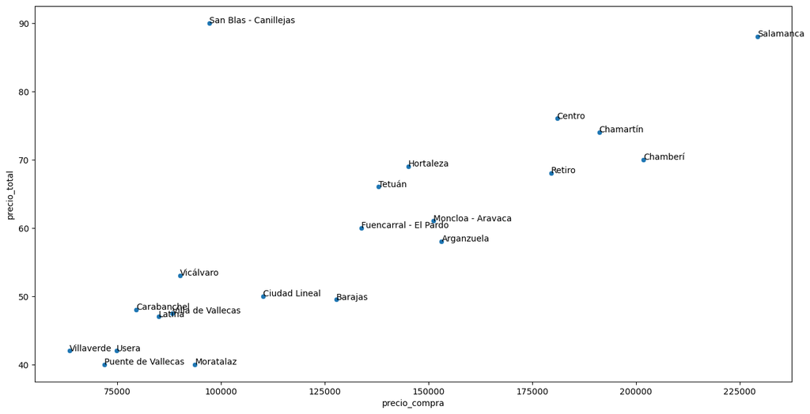

Existe una clara correlación entre el precio de compra en cada distrito y el precio que es posible cobrar.

Claramente se perciben tres clusters de bajo-bajo, medio-medio y alto-alto.

Y la excepción de San Blas que se conoce por qué es.

Por tanto, como era esperable no hay a priori ningúna conclusión valiosa clara a este nivel.

Se repite el análisis a nivel de barrio para ver si se identifica algo.

| neighbourhood | precio_total | precio_compra |
| --- | --- | --- |
| Abrantes | 35.5 | 79612.5 |
| Acacias | 53.8 | 153187.5 |
| Adelfas | 54.0 | 251370.0 |
| Aeropuerto | 41.3 | 127837.5 |
| Aguilas | 47.0 | 85012.5 |
| ... | ... | ... |
| Valverde | 62.5 | 133800.0 |
| Ventas | 42.0 | 110250.0 |
| Vinateros | 50.0 | 93750.0 |
| Vista Alegre | 50.0 | 79612.5 |
| Zofío | 36.4 | 74812.5 |

128 rows × 2 columns

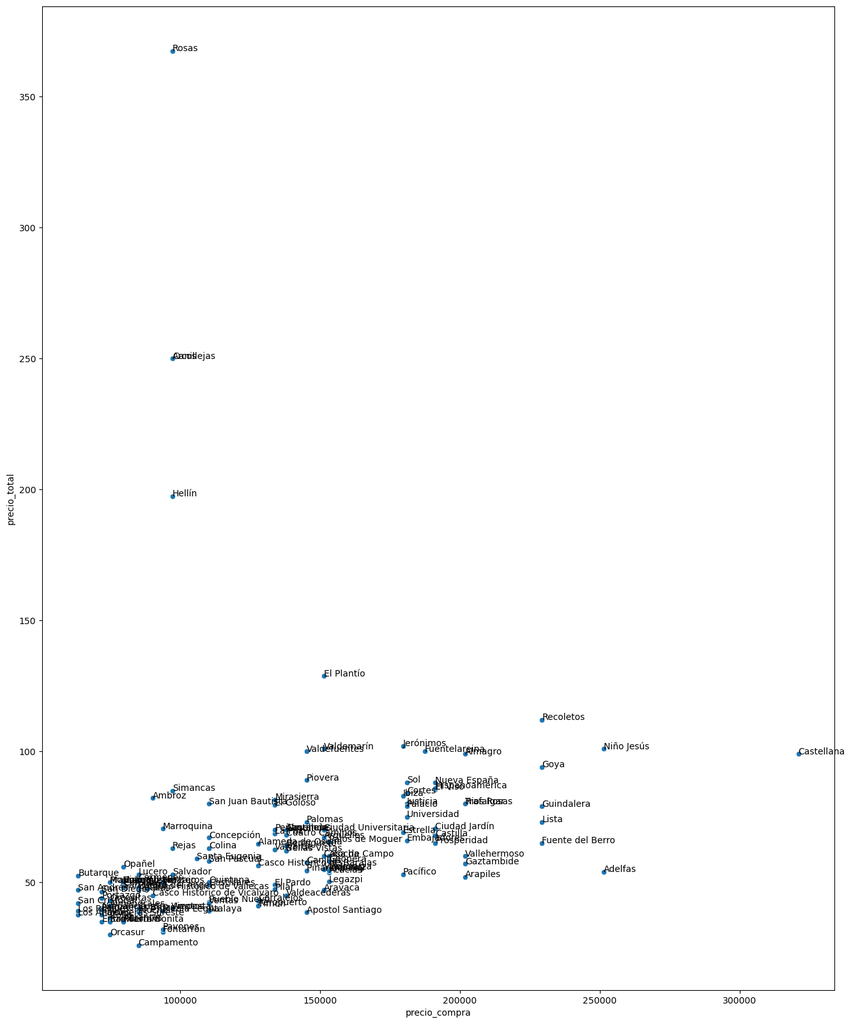

A este nivel se tiene:

- 3 barrios que sobresalen, posiblemente los 3 sean de San Blas
- Dentro de cada grupo de bajo-medio-alto es posible empezar a separarar
  - Bajo: Simancas, Ambroz, Marroquina, San Juan Bautista
  - Medio: El Plantio, Valdemarín, Valdefuentes
  - Medio-alto: Jerónimos, Fuentela reina
  - Alto: Recoletos

*Insight 2*: Existen ciertos barrios que a priori pueden maximizar la relación costo-ingreso y además, es posible segmentarlo por el tipo calidad del inmueble en el que haya interés de inversión.

```
array(['San Blas - Canillejas'], dtype=object)
```

**¿Qué factores, a parte de la localización, determinan el precio del alquiler?**

Para responder a esta pregunta es posible construir un minicubo, ya que se han discretizado las variables de análisis.

|  | bedrooms_disc | accommodates_disc | beds_disc | number_of_reviews_disc | precio_total | precio_compra |
| --- | --- | --- | --- | --- | --- | --- |
| 0 | 01_Una | 0-3 | 1 | 49-744 | 60.0 | 191175.0 |
| 1 | 01_Una | 0-3 | 1 | 5-48 | 31.0 | 85012.5 |
| 2 | 03_Tres | 5-16 | 3-24 | 1-4 | 50.0 | 275737.5 |
| 3 | 01_Una | 0-3 | 1 | 5-48 | 92.0 | 181012.5 |
| 4 | 01_Una | 0-3 | 1 | 49-744 | 26.0 | 153187.5 |
| ... | ... | ... | ... | ... | ... | ... |
| 17705 | 01_Una | 0-3 | 1 | 1-4 | 29.0 | 181012.5 |
| 17706 | 01_Una | 0-3 | 1 | 1-4 | 29.0 | 181012.5 |
| 17707 | 01_Una | 0-3 | 1 | 1-4 | 29.0 | 181012.5 |
| 17708 | 01_Una | 0-3 | 1 | 1-4 | 29.0 | 229275.0 |
| 17709 | 01_Una | 0-3 | 1 | 1-4 | 33.0 | 181012.5 |

17710 rows × 6 columns

|  | precio_total | precio_compra | variable | value |
| --- | --- | --- | --- | --- |
| 0 | 60.0 | 191175.0 | bedrooms_disc | 01_Una |
| 1 | 31.0 | 85012.5 | bedrooms_disc | 01_Una |
| 2 | 50.0 | 275737.5 | bedrooms_disc | 03_Tres |
| 3 | 92.0 | 181012.5 | bedrooms_disc | 01_Una |
| 4 | 26.0 | 153187.5 | bedrooms_disc | 01_Una |
| ... | ... | ... | ... | ... |
| 70835 | 29.0 | 181012.5 | number_of_reviews_disc | 1-4 |
| 70836 | 29.0 | 181012.5 | number_of_reviews_disc | 1-4 |
| 70837 | 29.0 | 181012.5 | number_of_reviews_disc | 1-4 |
| 70838 | 29.0 | 229275.0 | number_of_reviews_disc | 1-4 |
| 70839 | 33.0 | 181012.5 | number_of_reviews_disc | 1-4 |

70840 rows × 4 columns

| variable | value | precio_total | precio_compra |
| --- | --- | --- | --- |
| accommodates_disc | 0-3 | 50.0 | 181012.5 |
|  | 4 | 86.0 | 181012.5 |
|  | 5-16 | 126.0 | 253417.5 |
| bedrooms_disc | 01_Una | 56.0 | 181012.5 |
|  | 02_Dos | 100.0 | 253417.5 |
|  | 03_Tres | 140.0 | 325822.5 |
|  | 04_Cuatro o mas | 204.0 | 434430.0 |
| beds_disc | 1 | 59.0 | 181012.5 |
|  | 2 | 100.0 | 253417.5 |
|  | 3-24 | 139.0 | 275737.5 |
| number_of_reviews_disc | 1-4 | 70.0 | 181012.5 |
|  | 49-744 | 68.0 | 181012.5 |
|  | 5-48 | 69.0 | 181012.5 |

Sobre el minicubo se analiza cada variable.

| value | precio_total | precio_compra |
| --- | --- | --- |
| 01_Una | 56.0 | 181012.5 |
| 02_Dos | 100.0 | 253417.5 |
| 03_Tres | 140.0 | 325822.5 |
| 04_Cuatro o mas | 204.0 | 434430.0 |

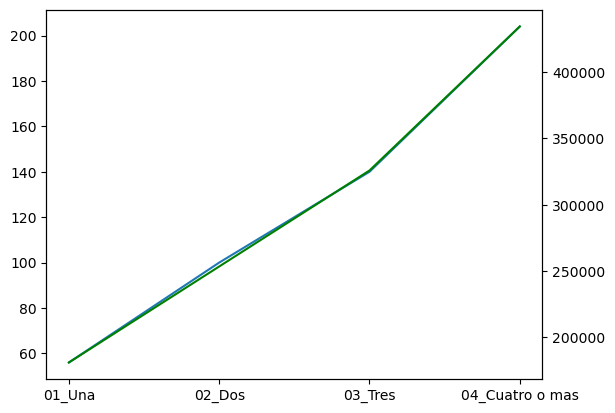

En cuanto al número de habitaciones no hay nada que destacar.

Existe una relación casi perfecta entre el precio de compra y el precio total que se puede cobrar.

Parte de este efecto puede ser artificial, ya que usamos el número de habitaciones para calcular el precio total como el precio de compra.

| value | precio_total | precio_compra |
| --- | --- | --- |
| 1 | 59.0 | 181012.5 |
| 2 | 100.0 | 253417.5 |
| 3-24 | 139.0 | 275737.5 |

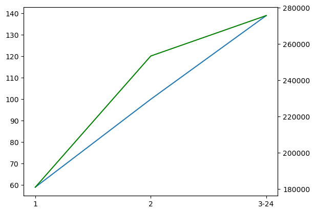

En cuanto al número de camas si hay una conclusión:

*Insight 3*: el número de camas a evitar es 2. O bien se incluye una cama o se intenta meter todas las posibles.

Dado que no había este efecto en el número de habitaciones ¿podría ser que los propietarios estén intentando meter muchas más camas que habitaciones para maximizar el ingreso?

Se analiza, por ejemplo, con los pisos de una habitación:

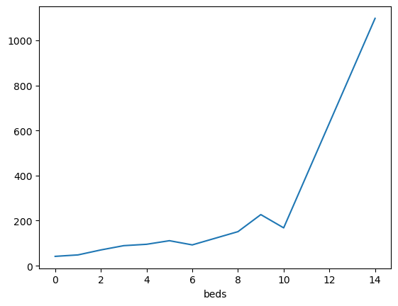

Efectivamente aquí hay algo, ya que figura que para pisos de una habitación hay gente que está metiendo hasta decenas de camas!

Sería un tema a explorar con más detalle y comentar con alguien que tenga el conocimiento del negocio.

Otros ejemplos:

|  | level_0 | index | id | name | host_id | neighbourhood_group | neighbourhood | latitude | longitude | room_type | price | minimum_nights | calculated_host_listings_count | availability_365 | description | host_is_superhost | accommodates | bedrooms | beds | number_of_reviews | review_scores_rating | review_scores_communication | review_scores_location | precio_m2 | distrito | precio_total | ocupacion | bedrooms_disc | accommodates_disc | … |
| --- | --- | --- | --- | --- | --- | --- | --- | --- | --- | --- | --- | --- | --- | --- | --- | --- | --- | --- | --- | --- | --- | --- | --- | --- | --- | --- | --- | --- | --- | --- |
| 357 | 357 | 357 | 1044902 | Masía el Ferrajón | 5751753 | Moncloa - Aravaca | Ciudad Universitaria | 40.46549 | -3.75115 | Private room | 112 | 2 | 1 | 0 | <b>The space</b><br />Masía el Ferrajón featur... | f | 16 | 1.0 | 14.0 | 0 | NaN | NaN | NaN | 4033 | Moncloa - Aravaca | 1097.6 | 100 | 01_Una | 5-16 | … |
| 605 | 605 | 605 | 2143824 | The Hat Madrid - 10 people shared | 10940437 | Centro | Sol | 40.41511 | -3.70804 | Shared room | 24 | 1 | 6 | 364 | 10 people shared room with shared bathroom. <b... | t | 10 | 1.0 | 10.0 | 91 | 4.57 | 4.69 | 4.84 | 4827 | Centro | 168.0 | 0 | 01_Una | 5-16 | … |
| 710 | 710 | 710 | 3011110 | The Hat Madrid-Compartida 10 pers 2 | 10940437 | Centro | Embajadores | 40.41311 | -3.70621 | Shared room | 24 | 1 | 6 | 364 | The Hat Madrid es el primer Boutique Hostel de... | t | 10 | 1.0 | 10.0 | 28 | 4.56 | 4.81 | 4.93 | 4827 | Centro | 168.0 | 0 | 01_Una | 5-16 | … |
| 11848 | 11848 | 11848 | 39600798 | Bed in a 10-Bed Dormitory In the Centre of Madrid | 304035848 | Centro | Justicia | 40.42710 | -3.69912 | Shared room | 20 | 1 | 13 | 351 | Low-key, hostel-style setup on a tree-lined st... | f | 1 | 1.0 | 10.0 | 2 | 5.00 | 5.00 | 5.00 | 4827 | Centro | 140.0 | 3 | 01_Una | 0-3 | … |
| 13340 | 13340 | 13340 | 42492960 | Apartamento dúplex 10camas en literas | 338384437 | Tetuán | Cuatro Caminos | 40.44959 | -3.70138 | Private room | 298 | 1 | 1 | 364 | Vivienda en planta baja con 10 plazas distribu... | f | 10 | 1.0 | 10.0 | 1 | 5.00 | 4.00 | 5.00 | 3678 | Tetuán | 2086.0 | 0 | 01_Una | 5-16 | … |
| 15722 | 15722 | 15722 | 48855617 | habitaciones en una casa tranquila, en el centro | 194738186 | Salamanca | Fuente del Berro | 40.42604 | -3.66373 | Private room | 36 | 2 | 1 | 359 | Es una casa que tiene dos habitaciones que se ... | f | 5 | 1.0 | 9.0 | 0 | NaN | NaN | NaN | 6114 | Salamanca | 226.8 | 1 | 01_Una | 5-16 | … |

Se analiza ahora por el número de huéspedes aceptados

| value | precio_total | precio_compra |
| --- | --- | --- |
| 0-3 | 50.0 | 181012.5 |
| 4 | 86.0 | 181012.5 |
| 5-16 | 126.0 | 253417.5 |

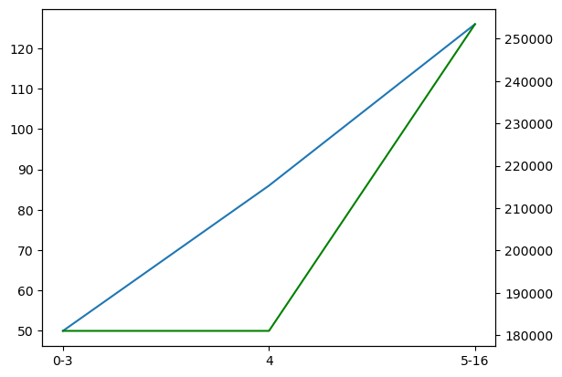

Por último, se analiza la variable que se construyó -cercanía a un punto de interés- para ver si tiene efecto sobre el precio de las habitaciones.

Es posible construir muchas de este tipo y repetir el análisis con todas.

En este caso, se ha construído la distancia a la Puerta del Sol y se evalua solamente para los distritos que esto puede ser relevante, es decir, los más céntricos.

Para ello, primero se calcula la distancia media por distrito y se elige un punto de corte.

```
distrito
Centro                    0.728581
Arganzuela                1.817840
Chamberí                  2.078790
Moncloa - Aravaca         2.130135
Retiro                    2.415432
Salamanca                 2.705209
Latina                    3.496952
Carabanchel               3.647956
Usera                     3.661376
Chamartín                 4.233216
Puente de Vallecas        4.233631
Tetuán                    4.572866
Ciudad Lineal             5.170226
Moratalaz                 5.242395
Villaverde                7.579665
Fuencarral - El Pardo     7.738933
San Blas - Canillejas     7.962141
Hortaleza                 8.132864
Vicálvaro                 8.396723
Villa de Vallecas         8.822907
Barajas                  11.593340
Name: pdi_sol, dtype: float64
```

Se corta en Latina incluído.

Y sobre esa selección se visualiza con un scatter.

```
['Centro',
 'Arganzuela',
 'Chamberí',
 'Moncloa - Aravaca',
 'Retiro',
 'Salamanca',
 'Latina']
```

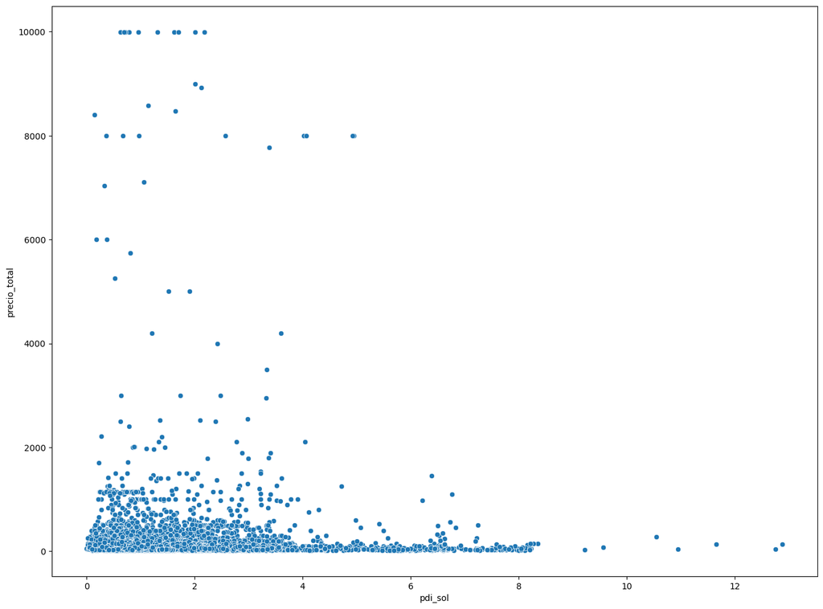

No parece haber una relación tan directa, como sería esperable, entre la distancia a la Puerta del Sol y el precio de alquiler.

*Insight 5*: estando dentro del distrito parece que la cercanía a puntos de interés no tiene tanto impacto como sería esperable. Eso abre la puerta a buscar inmuebles que estando en un distrito céntrico no estén justo al lado del pdi y por tanto, esperablemente tengan un precio de compra menor.

## Análisis geográfico sobre un mapa

El análisis geográfico es una disciplina en si misma, de considerable complejidad.

Se usará una alternativa que para el objeto del análisis es valiosa, además, de baja complejidad.

Lo único que se requiere son las coordenadas de latitud y longitud.

Se usarán las coordenadas de la Puerta del Sol ya disponibles.

Make this Notebook Trusted to load map: File -> Trust Notebook

[interactive chart not shown]

Por ejemplo, se analiza visualmente el insight sobre el distrito de San Blas.

Para representar los marcadores de todos los pisos se crea un bucle que va añadiéndolos al mapa.

Make this Notebook Trusted to load map: File -> Trust Notebook

[interactive chart not shown]

Esta representación está bien, pero se tiene que ir haciendo click en cada uno para visualizar el precio.

Sería más práctico si se dispone de un código de colores que indique visualmente el rango de precio.

Para ello, se crea una nueva variable discretizada y se cambia el marcador a un círculo de colores.

Make this Notebook Trusted to load map: File -> Trust Notebook

[interactive chart not shown]

*Insight 6*: Existen todavía muchos puntos amarillos y naranjas (precio relativamente bajo), lo cual puede indicar que todavía existe gran potencial para explotar más el factor de los eventos deportivos.

# COMUNICACIÓN DE RESULTADOS

## CONTEXTO DEL ANÁLISIS

La empresa ha seleccionado la ciudad de Madrid como candidata para buscar inmuebles en los que invertir con el objetivo de obtener rentabilidad mediante alquiler turístico.

Para ello, antes buscar oportunidades al azar, se ha encargado un análisis de Discovery que permita identificar estrategias o líneas de trabajo que ayuden a dirigir la actuación del equipo de valoraciones.

## OBJETIVOS

- Analizar las fuentes de datos públicas disponibles.
- Encontrar insights que ayuden a entender las características del mercado en esta ciudad.
- Guiar el trabajo de búsqueda del equipo de valoraciones.

Especialmente en cuanto a los principales ejes: precio del alquiler, niveles de ocupación y precio de compra.

## DETALLE DE LOS PRINCIPALES RESULTADOS

### Existen 10 barrios con alto potencial de inversión

- Se han localizado 10 barrios que a priori, pueden maximizar la relación costo-ingreso.
- Además, es posible segmentarlos por el tipo calidad del inmueble en el que nos interes invertir en 4 grandes grupos.
- Estos son los 10 barrios donde comenzar a buscar oportunidades concretas:
  - Inversión baja: Simancas, Ambroz, Marroquina, San Juan Bautista
  - Inversión media: El Plantio, Valdemarín, Valdefuentes
  - Inversión media-alta: Jerónimos, Fuentela reina
  - Inversión alta: Recoletos

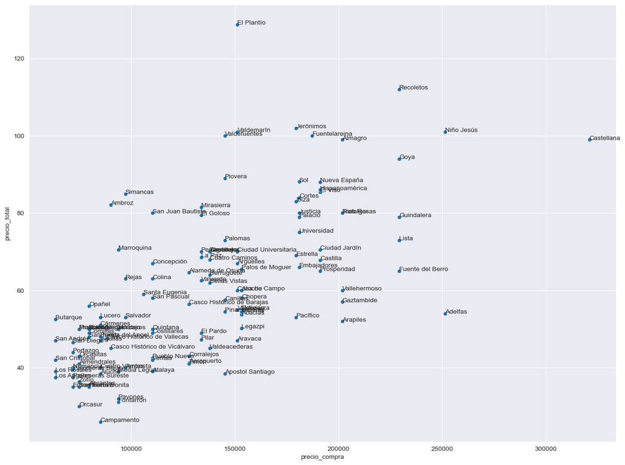

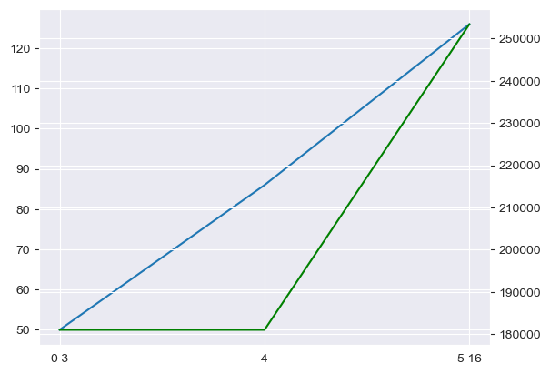

### Buscar inmuebles que estando en uno de los barrios identificados no estén necesariamente cerca de puntos de interés

- Previsiblemente tendrán menor precio de compra.
- Parece que la cercanía a puntos de interés no tiene un especial impacto sobre el precio de alquiler.

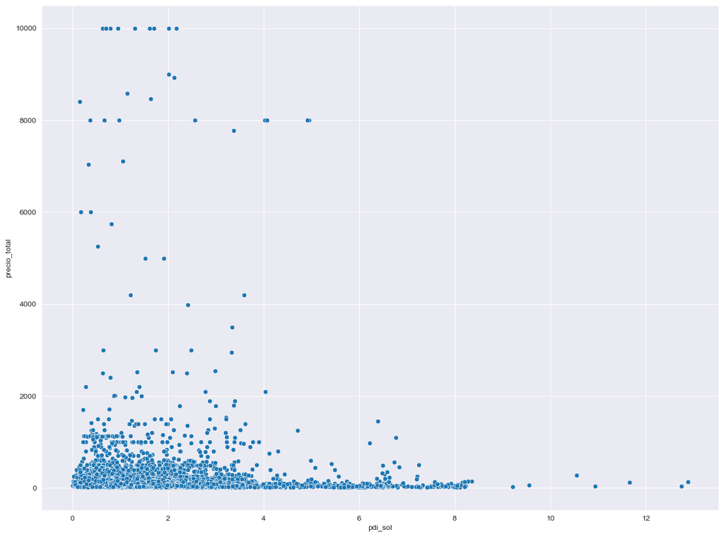

### Evaluar el desarrollo de un nuevo producto basado en el alquier para momentos concretos de alto interés deportivo

- Buscar oportunidades en el barrio de San Blas.
- Todavía existen muchos alquileres que no están explotando este potencial.

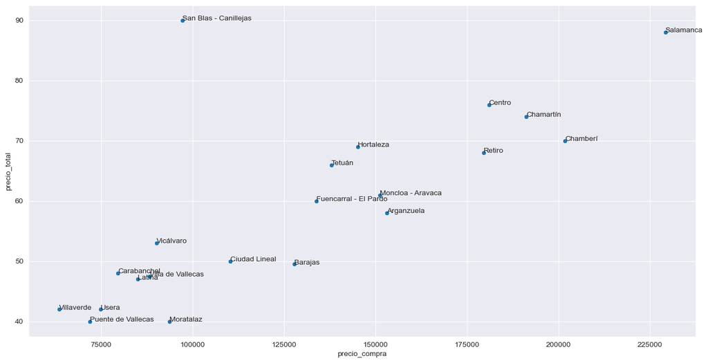

Make this Notebook Trusted to load map: File -> Trust Notebook

[interactive chart not shown]